# Development Research in Practice

### Tidying raw data

Though raw data can be acquired in all shapes and sizes, it is most commonly received as one or multiple data tables. These data tables can organize information in multiple ways, and not all of them result in easy-to-handle datasets. Fortunately, a vast literature of database management has identified the format that makes interacting with the data as easy as it can be. We call data in such format **tidy**. A data table is tidy when each column represents one **variable**,[^198] each row represents one observation, and all variables in it have the same unit of observation. Every other format is *untidy*. This may seem trivial, but raw data, and raw survey data in particular, is rarely received in a tidy format.

The most common case of untidy raw data encountered in development research is a dataset with multiple units of observations stored in the same data table. Take, for example, a household survey that includes household-level questions, as well as a household member roster. Such raw datasets usually consists of a single data table where questions from the household member roster are saved in different columns, one for each member, with a corresponding member suffix, and household-level questions are represented by one column each. When your rows include multiple nested observational units, then the identifying variable does not identify all observations on that row, as there is more than one unit of observation on the same row.

Survey data containing nested units of observation is typically imported from survey platforms in **wide format**.[^199] Wide format data could have, for instance, one column for a household-level variable (for example `ownsfridge`), and a few columns for household member-level variables (for example `sex_1`, `sex_2`). Raw data is often saved in this format because it’s the most efficient way to transfer it: adding different levels of observation into the same data table allows for data to be transferred in a single file. However, this leads to the widespread practice of interacting with data in wide format, although doing so is often inefficient and error-prone.

To understand how dealing with wide data can be complicated, imagine you need to calculate the share of women in each household using the household level data described above. In a wide data table you will either have to first create variables counting the number of women and the total number of household members, and then calculate the share, or you will have to transform the data to a different format. In a tidy data table, however, where each row is a household member, you can easily aggregate the share of women by household, without additional steps, and then merge the result to the household-level data tables. Tidy data tables are also easier to clean, as each attribute only needs to be checked once, and each column corresponds directly to one question in the questionnaire. Finally, as you will see in Chapter 6, summary statistics and distributions are much simpler to generate from tidy data tables.

As mentioned earlier, there are unlimited ways for data to be untidy; wide format is only one of those ways. Another example is a data table containing both information on transactions and on the firms involved in each transaction. In this case, the firm-level information will be repeated for all transactions a given firm was involved in. Analyzing data in this format would give more weight to firms that conducted more transactions, which may not be consistent with the research design.

The basic process behind tidying a data table is simple: first, identify all the variables that were measured at the same level of observation; second, create separate data tables for each level of observation; and third, reshape[^200] the data and remove duplicated rows until each data table is uniquely and fully identified by the identifying variable that corresponds to its unit of observation. Reshaping data tables is the most intricate task in data cleaning; you should be very familiar with commands such as `reshape` in Stata and `pivot` in R. You must be sure that identifying variables are consistent across data tables, so they can always be linked. Reshaping is the type of transformation we referred to in the example of how you calculate the share of women in a wide data set. The important difference is that in a tidy workflow, instead of transforming the data for each operation, this transformation is done once for all data during cleaning, making all subsequent operations much easier.

In the earlier household survey example, household-level variables will be stored in one tidy data table, and household-member variables are reshaped and stored in a separate, member-level, tidy data table, which also contains the household ID for each individual. The household ID is intentionally duplicated in the household members data table to allow one or several household members to be linked to the same household data. The unique identifier for the household member-level data data will be either a single household member ID or a combination of household ID and household member ID. In the transaction data example, the result of the tidying process would be one transaction-level data table, containing variables indicating the ID of all firms involved; and one firm-level data table with a single entry for each firm. Then, firm-level analysis is easily done by calculating appropriate statistics in the transactions data table (in Stata, often through `collapse`) and then merging or joining those results to the firms data table.

In a tidy workflow, your clean dataset is a set of one or more tidy data tables. In both examples above, your clean dataset is made up of two tidy data tables. There must be a clear way to connect each tidy data table to a master dataset, and thereby also to all other datasets. To implement this, you need to decide which data table is the main data table; that data table’s unit of observation will be the main unit of observation of your dataset. The main unit of observation must directly correspond to a master dataset, and be listed in the data linkage table. All other data tables in your dataset must have an unambiguous way to merge with the main data table. This way, it will be possible to link all data points in all your project’s datasets to each other. We recommend that you save your datasets as a folder, in which the main data table shares the same name as the folder, and the name of all other data tables start with the same name, but are suffixed with the unit of observation for that data table.

In the household dataset example, the household-level data table would be the main table. This means that there must be a master dataset for households. (You may have a master dataset for household members as well if you think it is important for your research, but it is not strictly required.) The household data set would then be stored in a folder called, for example, `baseline-hh-survey/`. In that folder you would save both the household-level data table with the same name as the folder, for example `baseline-hh-survey.csv`, and the household member-level data named in the same format but with a suffix, for example `baseline-hh-survey-hhmember.csv`.

The tidying process gets more complex as the number of nested groups increases. That means the steps of identifying the unit of observation of each variable and reshaping the separated data tables need to be repeated multiple times. However, the more nested groups a dataset includes, the more efficient it is to deal with tidy data as compared to untidy. Cleaning and analyzing wide datasets, in particular, is a repetitive and error-prone process.

The next step of data cleaning, data quality monitoring, may involve comparing different units of observation. Aggregating sub-units to compare to a higher unit is much easier with tidy data, which is why we suggest tidying data as the first step in the cleaning workflow. If you are conducting primary data collection, you can start preparing or coding the data tidying even before the data is acquired, since you will know in advance the exact format in which the data will be received. In the case of survey data, tidying datasets will guarantee a one-to-one correspondence between questions in the questionnaire and columns in the data. Preparing the data for analysis, the last task in this chapter, is much simpler when that is the case.

## Assuring data quality

Whether you are acquiring data from a partner or collecting it directly, it is important to make sure that data faithfully reflects ground realities. You should carefully examine and clean any data you are about to use. When reviewing raw data, you will inevitably encounter data entry mistakes, such as typos and inconsistent values. Whether your team is conducting a survey or you are receiving administrative data from a partner, the key aspects to have in mind are data completeness, consistency and distribution. Data quality assurance checks should be performed as soon as the data is acquired. When data is being collected and transferred to the team in real-time, this means conducting high-frequency checks. Primary data require extra attention to quality checks, as data entry by humans is more susceptible to errors, and the research team will be the only line of defense between data issues and the data analysis. Survey-specific quality monitoring protocols are discussed in Chaper 4.

### Implementing data quality checks

Data quality checks should carefully inspect key treatment and outcome variables to ensure that the data quality of core study variables is uniformly high, and that additional effort is centered where it is most important. They should be run every time data is received to flag irregularities in the acquisition progress, in sample completeness, or in response quality. The faster issues are identified, the more likely they are to be solved. Once the field team has left a survey area, or high-frequency data has been deleted from a server, it may be impossible to verify whether data points are correct or not. Even if the research team is not receiving data in real-time, the data owners may not be as knowledgeable about the data, or even as responsive to the research team queries, as time goes by. `ipacheck`[^201] is a very useful Stata command that automates some of these tasks, regardless of the data source.

It is important to check continuously that the observations received match the intended sample. In surveys, electronic survey software often provides case management features through which sampled units are directly assigned to individual enumerators. For data received from partners, such as administrative data, this may be harder to validate. In these cases, cross-referencing with other data sources can help to ensure completeness. It is often the case that raw data includes duplicate or missing entries, which may occur due to typos, failed submissions to data servers, or other mistakes.[^202] Issues with data transmission often result in missing observations, particularly when large datasets are being transferred, or when data is being collected in locations with limited internet connection. Keeping a record of what data was submitted, and comparing it to the data received as soon as transmission is complete reduces the risk of noticing that data is missing when it is no longer possible to recover it.

Once data completeness is confirmed, observed units must be validated against the expected sample: this is as straightforward as merging the sample list with the data received and checking for mismatches. Reporting errors and duplicate observations in real time allows for efficient corrections.[^203] `ieduplicates` provides a workflow for resolving duplicate entries with the data provider. For surveys, it is also important to track data collection progress to monitor attrition, so that it is clear early on if a change in protocols or additional tracking will be needed.[^204] Remember to also check survey completion rates and sample compliance by surveyors and survey teams, and compare data missingness across administrative regions, to identify any clusters that may be providing data of suspect quality.

Quality checks should also include checks of response quality and consistency. For example, whether the values for each variable fall within the expected range, and related variables do not contradict each other.[^205] Electronic data collection systems often incorporate many quality control features, such as range restrictions and logical flows. Data received from systems that do not include such controls should be checked more carefully. Consistency checks are project specific, so it is difficult to provide general guidance. A detailed knowledge of the variables in the dataset and a careful examination of the analysis plan is the best way to prepare. Examples of inconsistencies in survey data would include cases where a household reports having cultivated a plot in one module, but does not list any cultivated crops in another. Response consistency should be checked across all datasets, as this is much harder to automate. For example, if two sets of administrative records are received, one with hospital level information and one with data on each medical staff, the number of entries in the second set of entries should match the number of employed personnel in the first one.

Finally, no amount of pre-programmed checks can replace actually looking at the data. Of course that doesn’t mean eye checking each data point, but rather plotting and tabulating distributions for your main variables of interest. This will help you identify outliers and other potentially problematic patterns that you had not foreseen. A common source of outliers values in survey data are typos, but they can also occur in admin data if, for example, the unit reported changed over time, but the data was stored with the same variable name. Identifying unforeseen patterns in the distribution will also help you gather relevant information, for example whether there was no harvest data because of a particular pest in the community or if the unusual call records in a particular area caused by temporary downtime of a tower. Analysis of metadata and paradata can also useful in assessing data quality. For example, electronic survey software generates automatically collected timestamps and trace histories, showing when data was submitted, how long enumerators spent on each question, and how many times answers were changed before or after the data was submitted.

## Processing confidential data

When implementing the steps discussed up to this point, you are likely to be handling confidential data. Effective data quality monitoring frequently requires you to identify the individual observations in your dataset, and the people or other entities who provided the information. Using identified data allows you to quickly follow up on and resolve identified issues. Handling confidential data such as **personally-identifying information** requires a secure environment and, typically, decryption. De-identifying the data will allow you to simplify that workflow, and will also reduces the risk of harmful leaks. This section describes how to de-identify data in order to share it with a wider audience.

### Protecting research subject privacy

Most development data involves human subjects.[^206] As a researcher, you may have access to personal information about your subjects: where they live, how much income they have, whether they have committed or been victims of crimes, their names, their national identity numbers, and other sensitive data.[^207] There are strict requirements for safely storing and handling personally-identifying data, and it is the responsibility of the research team to satisfy these requirements.[^208] Everyone working with human subjects research should have completed an ethics certification course.[^209] A plan for secure data handling is typically also required for IRB approval.

The best way to avoid risk is to minimize interactions with PII as much as possible. First, only collect personally-identifying information that is strictly necessary for the research. Second, avoid the proliferation of copies of identified data. There should never be more than one copy of the raw identified dataset in the working project folder, and it must always be encrypted. Third, de-identify the data as early as possible in the workflow. Even within the research team, access to the identified data should be limited to team members who require it for their specific tasks. Data analysis that requires identifying information is rare and in most cases can be avoided by properly linking masked identifiers to research information such as treatment statuses and weights, then removing unmasked identifiers.

% De-identification vs anonymization Once data is acquired and the data quality checks described above are completed, the next task is typically to **de-identify** the data, by removing or masking all personally-identifying variables.[^210] Note that it is in practice impossible to **anonymize** data. There is always some statistical chance that an individual’s identity will be re-linked to the stored data – even if that data has had all directly identifying information removed – by using some other data that becomes identifying when integrated. For this reason, we typically recommend de-identification in two stages. The **initial de-identification** process, performed as soon as data is acquired, strips the data of direct identifiers, to create a working de-identified dataset that can be shared *within the research team* without the need for encryption. The **final de-identification* process, performed before data is publicly released, involves careful consideration of the trade-offs between risk of identifying individuals and the utility of the data, and typically requires the removal of a further level of indirect identifiers. The rest of this section describes how to implement both the initial and the final de-identification processes.

### Implementing de-identification

Initial de-identification reduces risk and simplifies workflows. Once you create a de-identified version of the dataset, you no longer need to interact directly with the encrypted data. Note that if the data tidying resulted in multiple raw data tables, each will need to be de-identified separately, but the workflow will be the same for all of them.

During the initial round of de-identification, datasets must be stripped of personally identifying information. To do so, you will need to identify all variables that contain such information. For data collection, where the research team designs the survey instrument, flagging all potentially identifying variables at questionnaire design stage simplifies the initial de-identification process. If you did not do that, or you received original data by another means, there are a few tools to help flag variables with personally-identifying data. JPAL’s `PII-scan` and IPA’s `PII_detection`, scan variable names and labels for common string patterns associated with identifying information.[^211] The World Bank’s `sdcMicro` lists variables that uniquely identify observations, but its more refined method and higher processing capacity requirement makes it better suited for final de-identification.[^212] The `iefieldkit` command `iecodebook` lists all variables in a dataset and exports an Excel sheet where you can easily select which variables to keep or drop.[^213]

Once you have a list of variables that contain confidential information, assess them against the analysis plan and first ask yourself for each variable: *will this variable be needed for the analysis?* If not, the variable should be dropped. Don’t be afraid to drop too many variables the first time, as you can always go back and extract additional variables from the raw data, but you cannot go back in time and drop a PII variable that was leaked.

For each confidential variable that is needed in the analysis, ask yourself: *can I encode or otherwise construct a variable that masks the confidential component, and then drop this variable?* For example, it is easy to encode identifiers for small localities like villages and only provide a meaningless numerical indicator showing which observations are in the same village without revealing which villages are included in the data. This is typically the case for most identifying information. If the answer to either of the two questions above is yes, all you need to do is write a script to drop the variables that are not required for analysis, encode or otherwise mask those that are required, and save a working version of the data. For example: after constructing measures of distance or area, drop the specific geolocations in the data; after constructing and verifying numeric identifiers in a social network module, drop all names. If confidential information is strictly required for the analysis and cannot be masked or encoded, then at least the confidential part of the data is required to remain encrypted and only be decrypted when used during in the data analysis process. Using confidential data in the analysis process does *not* justify storing or sharing it in an insecure way.

After initial de-identification is complete, your dataset will consist of one or multiple tidy, de-identified data tables. This is the dataset that you will interact with during the remaining tasks described in this chapter. Initial de-identification should not affect the usability of the data. Note that access to the initially de-identified data should still be restricted to the research team only, as indirect identifiers may still present a high risk if disclosure. It is common, and even desirable, for teams to make data publicly available once the tasks discussed in this chapter are concluded. This will allow other researchers to conduct additional analysis and to reproduce your finding. Before that can be done, however, you should further consider whether your data can be re-identified, in a process we call **final de-identification**, which will be discussed in more detail in Chapter 7.

## Cleaning and preparing data for analysis

The last step in the data cleaning process involves making the dataset easy to use and understand, and carefully examining each variable to document distributions and identify patterns that may bias the analysis. The resulting dataset will contain only the variables collected in the field, and no modifications to data points will be made, except for corrections of mistaken entries. You may have more data tables in your dataset now then originally received, and they may have a different *format*, but the information contained is still the same. Apart from the **cleaned dataset** (or datasets) itself, cleaning will also yield extensive documentation describing it.

Data cleaning yields in-depth understanding of the contents and structure of your data. This knowledge will be key to correctly constructing and analyzing final indicators, which we cover in the next chapter. Do not rush through this step! It is common for data cleaning to be the most time-consuming task in a project. In this section, we introduce some concepts and tools to make it more efficient and productive. The section is separated into three subtopics: exploring the data, making corrections, and recoding and annotating. They are separated here because they are different in nature, and should be kept separated in your code. In practice, however, they may all done at the same point in time.

### Exploring the data

The first time you interact with the data contents is during quality checks. However, these checks are are usually time-sensitive, and there may not be time to explore the data at length. During data cleaning, on the other hand, you will need to inspect each variable closely. Use tabulations, summary statistics, histograms and density plots to understand the structure of data, and look for patterns or irregularities. Think critically about what you see. You should ensure that the numerical values that appear are consistent with the information the variable represents. You should ensure that statistical distributions look realistic and are not highly clumped or skewed. You should confirm that related variables are consistent with each other. You should check for outliers and missing values. Then, you should assess if unusual or unexpected distributional patterns of any of these characteristics could be caused by data entry errors.

At this point, it is more important to document your findings than to directly address any irregularities found. There is a very limited set of changes that should be made to the raw data during cleaning. They are described in the next two sections, and are usually applied to each variable as you examine it. Most of the transformations that result in new variables will be done during **data construction**,[^214] a process discussed in the next chapter. For now, focus on creating a record of what you observe, and extensively documenting the data being explored. You will use this documentation when discussing with your team how to address irregularities once you get to the construction stage. This material will also be valuable during exploratory data analysis.

### Correcting data points

% Correct or not correct As mentioned earlier, corrections to issues identified during data quality monitoring are the only changes done to individual data points during the data cleaning stage. However, there is a lot of discussion about whether one should modify such data points at all. Some argue that follow-ups to the issues identified are costly and add limited value. Since it is not possible to check each and every possible data entry error, doing so can create a false sense of security from issues identified on a few main variables. Additionally, manually-inspected data may suffer from considerable inspector variability. In many cases, the main purpose of data quality checks is to detect fraud and identify problems with data collection protocols. On the other hand, there is also an argument to be made against keeping clear typing errors or not correcting missing values. We recommend correcting any entries that are clearly identified as errors. However, there is some subjectivity involved in deciding which cases fall into this category. A common rule of thumb is to include the set of corrections which are based on information that you have privileged access to and other research teams would not be able to make, and no more. Making this such decisions involve deep knowledge of the data and the particular circumstances or each research project.

Whether you decide to modify your data or not, you must keep a careful record of all issues that you identify. If no data points are modified, it may still be helpful to add flags to observations containing potentially problematic values, so you can verify how they affect results during analysis. If your team decides to follow up on and correct these issues, the follow-up process must also be thoroughly documented. Be very careful not to include confidential information in documentation that is not securely stored, or that you intend to release as part of a replication package or data publication. Finally, remember not to make changes directly to the raw data. Instead, any corrections must be done as part of data cleaning, applied through code, and saved to a new intermediate dataset.

### Recoding and annotating data

% Why recoding and annotating data are important The cleaned dataset is the starting point of data analysis. It will be extensively manipulated to construct analysis indicators, so it is important for it to be easily processed by statistical software. To make the analysis process smoother, anyone opening this dataset for the first time should have all the information needed to interact with it, even if they were not involved in the acquisition or cleaning process. This will save them time going back and forth between the dataset and its accompanying documentation.

% Encoding variables Often times, datasets are not imported into statistical software in the most efficient format. The most common example is string (text) variables: categorical variables and open-ended responses are often read as strings. However, variables in this format cannot be used for quantitative analysis. Therefore, categorical variables must be transformed into other formats, such as *factors* in R and *labeled integers* in Stata.[^215] Additionally, open-ended responses stored as strings usually have a high risk of including identifying information, so cleaning them requires extra attention. The choice names in categorical variables (called *value labels* in Stata and *levels* in R) should be accurate, concise, and directly linked to the data collection instrument. Adding choice names to categorical variables makes it easier to understand your data as you explore it, and thus reduces the risk of small errors making their way through into the analysis stage.

% Recoding missing values In survey data, it is common for non-responses such as “Don’t know” and “Declined to answer” to be represented by arbitrary survey codes. The presence of these values could bias your analysis, since they don’t represent actual observations of an attribute. They need to be turned into *missing values*. However, the fact that a respondent didn’t know how to answer a question is also useful information that would be lost by simply omitting all information. In Stata, this information can be elegantly conserved using extended missing values.[^216]

% Labeling variables We recommend that the cleaned dataset be kept as similar to the raw data as possible. This is particularly important regarding variable names: keeping them consistent with the raw data makes data processing and construction more transparent. Unfortunately, not all variable names are informative. In such cases, one important piece of documentation makes the data easier to handle: the variable dictionary. When a data collection instrument (for example a questionnaire) is available, it is often the best dictionary one could ask for. But even in these cases, going back and forth between files can be inefficient, so annotating variables in a dataset is extremely useful. In Stata, `variable labels}[^217] must always be present in a cleaned dataset. They should include a short and clear description of the variable. A lengthier description, that may include, for example, the exact wording of a question, may be added through *variable notes*. In R, it is less common to use variable labels, and a separate dataset with a variable dictionary is often preferred, but *data frame attributes* can be used for the same purpose.

Finally, any information that is not relevant for analysis may be removed from the dataset. In primary data, it is common to collect information for quality monitoring purposes, such as notes, duration fields and surveyor IDs. Once you are past the quality monitoring phase, these variables may be removed from your dataset. In fact, to make the data easier to handle, you may choose to start from a minimal set of variables, and add new ones as you clean them. To ensure the cleaned dataset file doesn’t get too big to be handled, use commands such as `compress` in Stata so the data is always stored in the most efficient format.

% Cleaning tools: iecodebook, tidyverse Although all these tasks are key to making the data easy to use, implementing them can be quite repetitive and create convoluted scripts. The `iecodebook` command suite, part of the `iefieldkit` Stata package, is designed to make some of the most tedious components of this process more efficient.[^218] It also creates a self-documenting workflow, so your data cleaning documentation is created alongside that code, with no extra steps. As far as we know, currently there are no similar resources in R. However, the *tidyverse*[^219] packages compose a consistent and useful grammar to perform the same tasks.

### Documenting data cleaning

Throughout the data cleaning process, you will often need extensive inputs from the people responsible for data collection. Sometimes this is your research team, but often it will be someone else. It could be a survey team, the government ministry responsible for administrative data systems,[^220] the technology firm that generated remote sensing data, etc. Regardless of who originally collected the data, you should acquire and organize all documentation of how the data was generated.[^221] What type of documentation that is available depends on how the data was collected. For original data collection, this should include field protocols, data collection manuals, survey instruments, supervisor notes, and data quality monitoring reports. For secondary data, you should try to get the same type of information, but that is often not possible unless the data source is a well managed data publication. Independently of its exact composition, the data documentation should be stored alongside your data dictionary and codebooks. You will probably need these files during analysis, and they should be published along with the data, so other researchers may use them for their analysis as well.

## Looking ahead

This chapter introduced a workflow of formatting, cleaning, and quality assurance for the data that you obtained from the field or from partners, illustrated in the figure that follows. These tasks create your first research outputs using original data: an analysis-ready dataset. This dataset is well-structured to describe your units of analysis (it is “tidy”), it faithfully represents the measurements it was intended to collect, and it does not expose the identities of the people described by it. You have also now taken the time to fully understand the patterns and structures in your data, and annotated and labeled them for your use and use by others. Combined with the data map, this dataset will be the fundamental starting point for all analysis work. In the next chapter, we will walk through the steps needed to run the analyses originally specified in your analysis plan and answer your research question – or perhaps to find out you now have even more questions.

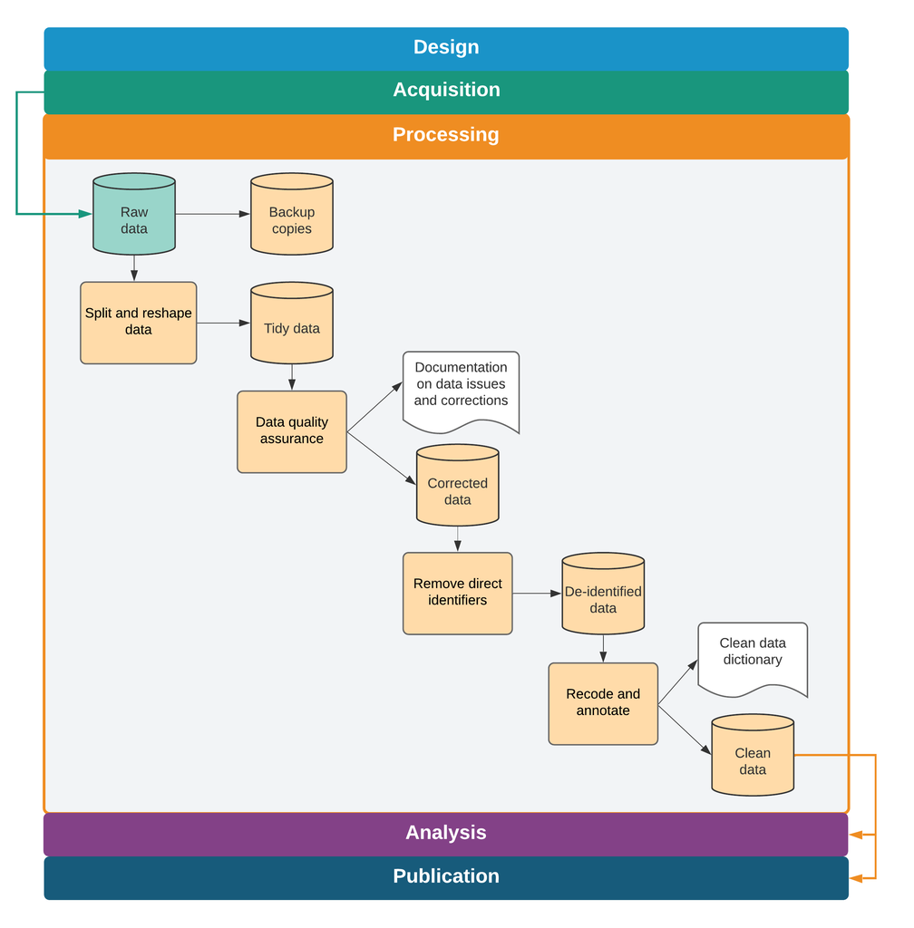

Data cleaning tasks and outputs

# 6 Constructing and analyzing research data

The process of data analysis is typically a back-and-forth discussion between people with differing skill sets. To effectively do this in a team environment, data, code and outputs must be well-organized and documented, with a clear system for version control, analysis scripts that can be run by all team members, and creation of research outputs fully automated. Putting in time upfront to structure the data analysis workflow in a reproducible manner pays substantial dividends throughout the process. Similarly, documenting research decisions made during data analysis is essential not only for research quality and transparency, but also for the smooth implementation of a project.

In this chapter, we discuss the necessary steps to transform cleaned raw data into informative analysis outputs such as tables and figures. The suggested workflow starts where the last chapter ended: with the outputs of data cleaning. The first section covers variable construction: transforming the raw data into economically meaningful indicators. The second section discusses the analysis code itself. We do not offer instructions on how to conduct specific analyses, as that is determined by research design, and there are many excellent existing guides. Rather, we discuss how to structure and document data analysis that is easy to follow and understand, for both the full research team members and research consumers. The final section discusses ways to automate common outputs so that your work is fully reproducible.

## Creating analysis datasets

For this chapter, we assume you are starting from one or multiple well-documented tidy[^222] datasets. We also assume that these datasets have gone through thorough quality checks and incorporate any corrections needed.[^223] The next step is to **construct**[^224] the variables that you will use for analysis; that is, to transform the cleaned data into analysis-ready data. It’s possible the data is ready for analysis as acquired, but in most cases it needs to be prepared by integrating different datasets and creating derived variables (dummies, indices, and interactions, to name a few[^225] ). The derived indicators you will construct should be planned during research design, with the pre-analysis plan serving as a guide. During construction, data will typically be reshaped, merged, and aggregated to change the level of the data points from the **unit of *observation*** in the raw data to the **unit of *analysis*** .[^226]

Each analysis dataset is built to answer an analysis question. If the sub-samples and units of observation vary for different pieces of the analysis, you will probably need to create many purpose-built analysis datasets. In such cases, it is not good practice to try to create a single “one-size-fits-all” analysis dataset. For a concrete example of what this means, think of an agricultural intervention that was randomized across villages and only affected certain plots within each village. The research team may want to run household-level regressions on income, test for plot-level productivity gains, and check if village characteristics are balanced. Having three separate datasets for each of these three pieces of analysis will result in cleaner, more efficient, and less error-prone analytical code than if you started from a single analysis dataset and repeatedly transformed it.

### Organizing data analysis workflows

Construction follows data cleaning and should be treated as a separate task for two reasons. First, this helps to clearly differentiate error corrections (necessary for all data uses) from creation of analysis indicators (necessary only for specific analyses). Second, it helps to ensure that variable definitions are consistent across datasets. For example, take a project that has a baseline and an endline survey. Unless the two data collection instruments are exactly the same, which is preferable but often not the case, the data cleaning for each of these rounds will require different steps, and therefore will be done separately. However, the analysis indicators must be constructed in the exact same way, so they are comparable. To do this, you will require at least two separate cleaning scripts, and a unified construction script. Maintaining one construction script guarantees that you will not accidentally make changes to an indicator from one round while forgetting to update the other.

When we visualize the research workflow, variable construction precedes data analysis, as derivative variables need to be created before they are analyzed. In practice, however, as you analyze the data, it is often useful to revisit construction, and explore different subsets and transformations of the data. Even if construction and analysis are done concurrently, you should always code them in separate scripts. If every script that creates a table starts by loading a dataset, subsetting it, and manipulating variables, any edits to construction need to be replicated in all scripts. This increases the chances that at least one of them will have a different sample or variable definition. Coding all variable construction and data transformation in a unified script, separate from the analysis code, prevents such problems and ensures consistency across different outputs.

### Integrating multiple data sources

To create the analysis dataset, it is typically necessary to combine information from different data sources or different datasets with a common source. For the next few paragraphs, we call such operations “merges”, but they are also commonly referred to as “data joins”. As discussed in Chapter 3, this process should be documented using **data flowcharts**,[^227] and different data sources should only be combined in accordance with the data linkage table.[^228] For example, you may merge administrative data with survey data in order to include demographic information in your analysis, or you may want to integrate geographic information in order to include location-specific controls. To understand how to perform such operations, you will need to consider the unit of observation for each dataset, and their respective identifying variables. Merges are frequent and complex operations, which makes them a common source of error. Whichever statistical software you are using, take the time to read through the help file of merge commands and make sure you understand their options and outputs.

When writing the code to implement merge operations, a few steps can help avoid mistakes. First, before writing code to combine the datasets, write pseudocode to understand which observations you expect to be matched or not, and why. When possible, determine exactly which and how many matched and unmatched observations should result from the merge. The best tool you have to understand this is the three components of the data map discussed in chapter 3. Second, think carefully about whether you want to keep matched and unmatched observations, or only specific matching outcomes (e.g. to create a balanced panel), and add that to the pseudocode as well. Finally, run the code to merge the datasets, and compare the outcome to your expectations. Add comments to explain any exceptions, and make it so the code will return an error in case unexpected results show up in future runs.

To avoid unintentional changes to your data, pay close attention to merge results. Two that require careful scrutiny are missing values and dropped observations. Make sure to read about how each command treats missing observations: are unmatched observations dropped, or are they kept with missing values? Whenever possible, add automated checks in the script that throw an error message if the result is different than what you expect, or you may not notice changes in the outcome after running large chunks of code. Document changes to the number of observations in your comments, and explain why they are happening. If your are subsetting your data by keeping only matched observations, write down the reason why the observations differ across datasets, as well as why you are only interested in those that matched. The same applies when you are adding new observations from the merged dataset.

Some merges of data with different units of observation are more conceptually complex. Examples include: overlaying road location data with household data, using a spatial match; combining school administrative data, such as attendance records and test scores, with student demographic characteristics from a survey; or linking a dataset of infrastructure access points, such as water pumps or schools, with a dataset of household locations. In these cases, a key part of the research contribution is figuring out a useful way to combine the datasets. Since the conceptual constructs that link observations from the two data sources are important and can take many possible forms, it is especially important for the data integration to not be treated mechanically, and to be extensively documented, separately from other data construction tasks.

### Creating analysis variables

Once you have assembled variables from different sources into a single working dataset with the right raw information and observations, it’s time to create the derived indicators of interest for analysis. Before constructing new indicators, you must check and double-check units, scales, and value assignments of each variable that will be used. This is when you will use the knowledge of the data and the documentation developed during cleaning the most. First, check that all categorical variables have the same value assignment, such that labels and levels have the same correspondence across variables that use the same options. For example, it’s possible that in one question `0` means “no” and `1` means “yes”, while in another one the same answers were coded as `1` and `2`. (We recommend coding binary questions as either `1` and `0` or `TRUE` and `FALSE`, so they can be used numerically as frequencies in means and as dummies in regressions. This often implies re-expressing categorical variables like `gender` as binary variables like `woman`.) Second, make sure that any numeric variables you are comparing are converted to the same scale or unit of measure: you cannot add one hectare and two acres and get a meaningful number. New variables should be assigned functional names, and the dataset ordered such that related variables are together. Adding notes to each variable will make your dataset more user-friendly.

At this point, you will also need to decide how to handle any outliers or unusual values identified during data cleaning. How to treat outliers is a research question.[^229] There are multiple possible approaches, and the best choice for a particular case will depend on the objectives of the analysis. Whatever your team decides, make sure to explicitly note what the decision was and how it was made. Results can be sensitive to the treatment of outliers, so keeping the original variable in the dataset will allow you to test how much it affects your outputs. All these points also apply to imputation of missing values and other distributional patterns. As a general rule, never overwrite or delete original data during the construction process. Always create derived indicators with new names.

Two features of data create additional complexities when constructing indicators: research designs comprising multiple units of observation and analysis, and designs with repeated observations of the same units over time. When your research involves different units of observation, creating analysis datasets will probably mean combining variables measured at these different levels. If you followed our recommendations from Chapter 5, this means combining variables that are included in different tidy datasets. To make sure constructed variables are consistent across datasets, we recommend that each indicator be constructed in the dataset corresponding to its unit of observation. Once we have indicators at each unit of observation, they may be aggregated and/or merged to different units of analysis. Take the example of a project that acquired data at both the student and teacher levels. You may want to analyze the performance of students on a test while controlling for teacher characteristics. This can be done by assigning the teacher-level indicators to all the students in the corresponding class. Conversely, you may want to include average student test scores in the analysis dataset containing teacher-level variables. To do so, you would start from the constructed dataset at student level, average (using commands like `collapse` in Stata and `summarise` in R) the test scores of all students taught by the same teacher, and merge this teacher-level aggregate measure onto the original teacher dataset. You should be mindful of two aspects while performing such operations: the first is the correspondence between identifying variables at different levels, which should be documented in the **data linkage table**; the second is that they will necessarily involve merges, so all the steps outlined in the previous section should be applied.

Finally, creating a panel with survey data involves additional timing complexities. It is common to construct indicators soon after receiving data from a new survey round. However, creating indicators for each round separately increases the risk of using different definitions each time. Having a well-established definition for each constructed variable helps prevent that mistake, but the best way to guarantee it won’t happen is to create the indicators for all rounds in the same script. Say you constructed some analysis variables after baseline, and are now receiving midline data. Then the first thing you should do is create a cleaned panel dataset, ignoring the previous constructed version of the baseline data. Our team created `iefieldkit`’s `iecodebook append` subcommand to help you reconcile and append data from cleaned survey rounds or similar data collected from different contexts.[^230] This is done by completing an Excel sheet to indicate what changes in names, value assignments, and value labels should be made so the data is consistent across rounds or settings.[^231] By doing so, you are also creating helpful documentation about your data work. Once data tables are consistently appended, adapt your construction script so it can be used on the complete panel dataset. In addition to preventing inconsistencies and documenting your work, this process will also save you time and give you an opportunity to review your original code.

### Documenting variable construction

Because data construction involves translating concrete observed data points to measures of abstract concepts, it is important to document exactly how each variable is derived or calculated. Careful documentation is closely linked to the research principles discussed in the first chapter. It makes research decisions transparent, as anyone can read about how you defined each variable in your analysis, and what was the reasoning behind these decisions. By reading the documentation, someone unfamiliar with the project should be able to understand the contents of the analysis datasets, the steps taken to create them, and the decision-making process through your documentation. Ideally, they should also be able reproduce your steps and recreate the constructed variables. Therefore, documentation is an output of construction as relevant as the code and data, and it is good practice for papers to have an accompanying data appendix listing analysis variables and their definitions.

The development of construction documentation is a good opportunity to have a wider discussion with your team about creating protocols for variable definition, which will guarantee that indicators are defined consistently across projects. You must have a detailed account of how variables are created. This will be implemented in your code, but you should still add comments explaining in human language what you are doing and why. This is a crucial step both to prevent mistakes and to guarantee transparency. To make sure that these comments can be more easily navigated, it is wise to start writing a variable dictionary as soon as you begin making changes to the data.[^232] The variable dictionary can be saved in an Excel spreadsheet, a Word document, or even a plain text file. Whatever format it takes, it should carefully record how specific variables have been combined, recoded, and scaled. Whenever relevant, the code should point to these files to indicate where the definition are being implemented.

The `iecodebook export` subcommand is a good way to ensure you have easy-to-read documentation. When all your final indicators have been created, you can use it to list all variables in the dataset in an Excel sheet. You can then add the variable definitions to that file to create a concise metadata document. Take this opportunity to review your notes and make sure that your code is implementing exactly what is described in the documentation.

## Writing analysis code

### Organizing analysis code

The analysis stage usually starts with a process we call **exploratory data analysis**. This is when you are first looking for patterns in your data, creating descriptive graphs and tables, and trying different tests to understand your results. It progresses into **final analysis** when your team starts to decide which are the “main results”, or those that will make it into a research output. The way you deal with code and code outputs for exploratory and final analysis is different. During the exploratory stage, you will be tempted to write lots of analysis into one big, impressive, start-to-finish script. While this is fine when you are writing your research stream of consciousness into code, it leads to poor practices in the final code such as not clearing the workspace and not loading a fresh dataset before each analysis task.

To avoid mistakes, it’s important to take the time to organize the code that you want to keep, that is, the final analysis code, in an organized manner. The result is a curated set of polished scripts that will be part of a reproducibility package. A well-organized analysis script starts with a completely fresh workspace and, for each output it creates, explicitly loads data before analyzing it. This setup encourages data manipulation to be done earlier in the workflow (that is, in separate cleaning and construction scripts). It also prevents the common problem of having analysis scripts that depend on other analysis scripts being run before them. Such dependencies tend to require manual instructions for all necessary chunks of code to be run in the right order. We encourage you to code each task so it is completely independent of all other code, except for the master script. You can go as far as coding every output in a separate script, but the key is making sure you know which datasets are used for each output, and which code chunks implement each piece of analysis.

There is nothing wrong with code files being short and simple. In fact, analysis scripts should be as simple as possible, so whoever is reading them can focus on the concepts, not the coding. Research questions and statistical decisions should be incorporated explicitly in the code through comments, and their implementation should be easy to detect from the way the code is written. This includes clustering, sampling, and controlling for different variables, to name a few. If you have multiple analysis datasets, each of their names should be descriptive of the sample and unit of observation they contain. As your team comes to a decision about model specification, you can create functions and globals (or objects) in the master script to use across scripts. This is a good way to make sure specifications are consistent throughout the analysis. It also makes your code more dynamic, as it’s easy to update specifications and results through a master file without changing every script.

To create this setup, you will need to make sure that you have an effective data management system, including file naming, organization, and version control. Just as for the analysis datasets, you should name each of the individual analysis files descriptively. Code files such as `spatial-diff-in-diff.do`, `matching-villages.R`, and `summary-statistics.py` are clear indicators of what each file is doing, and allow you to find code quickly. If you intend to numerically order the script files to correspond to exhibits as they appear in a paper or report, leave this to near publication time, as you will constantly re-order them during data analysis.

### Visualizing data

**Data visualization** is increasingly popular, and is becoming a field in its own right.[^235] Although the same principles for coding exploratory and final data analysis apply to visualizations, creating them is usually more difficult than running a regression and exporting its results into a table. We attribute some of the difficulty of creating good data visualization to the difficulty of writing code to create them. The amount of customization necessary to create a nice graph can lead the relevant commands to become quite intricate. Making a visually compelling graph would already be hard enough if you didn’t have to go through many rounds of searching and reading help files to understand a command’s graphical options syntax. Although getting each specific element of a graph to look exactly the way you want can be hard, the solution to such problems is usually a single well-written search away, and we recommend you leave these details as the very last adjustments to make. In our experience, the trickiest part of using plotting commands is getting the data into the right format. Though both Stata and R have plotting functions that graph summary statistics, a good rule of thumb is to ensure that each observation in your dataset corresponds to one data point in your desired visualization. This may seem simple, but often requires the aggregation and reshaping operations discussed earlier in this chapter.

Based on DIME’s accumulated experience creating visualizations for impact evaluations, our team has developed a few resources to facilitate this workflow. First of all, we maintain easily-searchable data visualization libraries for both Stata[^236] and R.[^237] These libraries feature curated data visualization examples, along with source code and example datasets, so you get a good sense of what your data should look like before you can start writing code to create a visualization.[^238] The `ietoolkit` package also contains two commands to automate common impact evaluation graphs: `iegraph`[^239] plots the values of coefficients for treatment dummies, and `iekdensity` displays the distribution of an outcome variable across groups and adds the treatment effect as a note.

## Creating reproducible tables and graphs

A great number of outputs will be created during the course of a project. These will include both raw outputs such as tables and graphs and final products such as presentations, papers and reports. During exploratory analysis, your team will consider different approaches to answer research questions and present answers. Though it is best to be transparent about different specifications tried and tests performed, only a few will ultimately be considered “main results”. These will be **exported**[^240] from the statistical software. That is, they will be saved as tables and figures in format that is easier to interact with. For example, saving graphs as images will allow your team to quickly see them, as well as to add them as exhibits to other documents. When the first of these code outputs are being created, agree on where to store them, what software and formats to use, and how to keep track of them. This discussion will save you time and efforts on two fronts: you will spend less time formatting and polishing tables and graphs that will not make their way into final research products; and you will remember the different paths your team has already taken, so you don’t do the same thing twice. This section will take you through key elements to keep in mind when making workflow decisions and outputting results.

### Managing outputs

Decisions about storage of outputs are limited by technical constraints, and dependent on file format. Plain text formats like `.tex` and `.csv` and should be managed through version control systems like Git, as discussed in Chapter 2. Binary outputs like Excel files, PDFs, PowerPoints, or Word documents, on the other hand, should be kept in a synced folder. Exporting all raw outputs as plain text files, which can be done through all statistical software, facilitates the identification of changes in results. When you re-run your code from the master script, the outputs will be overwritten, and any changes (for example, in coefficients or number of observations) will be automatically flagged for you or a reviewer to check. Tracking changes to binary files is more cumbersome. They they use more space, which may cause slow down the cloud syncing. There may be exceptions to this general rule depending on the Git client you are using. GitHub Desktop, for example, displays changes in common binary image formats such as PNG files in an accessible manner.

You will need to update your outputs frequently. And if you have tried to recreate a result after a few months, you probably know that it can be hard to remember where the code that created it was saved. File naming conventions and code organization, including easily searchable file names and comments, play a key role in not re-writing scripts again and again. We recommend maintaining one “final” analysis folder and one folder with draft code or exploratory analysis. The latter contains pieces of code that are stored for reference, but not cleaned up to be included in any final outputs. Once an output presents a result in the clearest manner possible, it should be renamed and moved to the “final analysis” folder. It’s typically desirable to have the names of outputs and scripts linked – so, for example, `factor-analysis.do` creates `factor-analysis.eps` and so on. Document output creation in the master script that runs your code, so that before the line that runs a particular analysis script there are a few lines of comments listing datasets and functions that are necessary for it to run, as well as all outputs created by that script.

Knowing how your code outputs will be used will help you decide the best format to export them. You can often save figures into different formats, such as `.eps`, `.png`, `.pdf` or `.jpg`. However, the decision between using Office Suite software such as Word and Power Point versus LaTeX and other plain text formats may influence how you write your code, as this choice often implicates in the use of a particular command. We strongly recommend that you chose software to create final products that can be linked to raw outputs in such a way that they are updated in the paper or presentation every time changes are made to them. We broadly call files that have this feature **dynamic documents**, and they will be discussed in more detail in the final section of this chapter.

### Exporting analysis outputs

As briefly discussed in the previous section, you do not necessarily have to export each and every table and graph created during exploratory analysis. Most statistical software allow you to review results interactively, and this is often preferred at this stage. Final analysis scripts, on the other hand, must export outputs that are ready to be included in a paper or report. No manual edits, including formatting, should be necessary after exporting final outputs. Manual edits are difficult to reproduce; the less you need them, the more reproducible your output is. You may think that it’s not worth coding a small formatting adjustment, but you will inevitably need to make changes to the output, and automating them will save you time by the end of the process. (However, don’t spend much time formatting tables and graphs until you have come to a decision about which will be used for your final product.[^241] ) Polishing final outputs can be a time-consuming process, and you want to do it as few times as possible.

We cannot stress this enough: do not set up a workflow that requires copying and pasting results. Copying results from Excel to Word is error-prone and inefficient. Copying results from a software console is risk-prone, even more inefficient, and totally unnecessary. The amount of work needed in a copy-paste workflow increases rapidly with the number of tables and figures included in a research output, and so do the chances of having the wrong version of a result in a paper or report.

If you need to create a table with a very specific format that is not automated by any command you know, consider writing it manually (Stata’s `filewrite` and R’s `cat()`, for example, allow you to do that). This will allow you to write a cleaner script that focuses on the econometrics, and not on complicated commands to create and append intermediate matrices. Keep in mind that final outputs should be self-standing. This means it should be easy to read and understand them with only the information they contain. Make sure labels and notes cover all relevant information included in your code and comments that are not otherwise visible in the output. Examples of information that should be included in labels and notes include sample, unit of observation, unit of measurement, and variable definition.[^247]

## Increasing efficiency of analysis with dynamic documents

**Dynamic documents**[^248] are a broad class of tools that enable a streamlined, reproducible workflow. The term “dynamic” can refer to any document-creation technology that allows the inclusion of explicitly encoded linkages to raw output files. This means that, whenever outputs are updated, the next time the document is loaded or compiled, it will automatically include all changes made to all outputs without any additional intervention from the user. This is not possible in tools like Microsoft Office, although there are tools and add-ons that produce similar functionality. In Word, by default, you have to copy and paste each object individually whenever tables, graphs, or other inputs have to be updated. This workflow becomes more complex as the number of inputs grows, increasing the likelihood of making mistakes or missing updates. Dynamic documents prevent this from happening by managing document compilation and inclusion of inputs in a single integrated process, so you can skip the copying and pasting altogether.

### Conducting dynamic exploratory analysis

Whatever software you are using, what matters is that you make sure to implement a self-updating process for table and figures. We have given a few recommendations as to what we believe to be best practices, but you will need to find out what works for your team. If your team has decided to use Microsoft Office, for example, there are still a few options to avoid problems with copy-pasting. The easiest solution may be for the less code-savvy members of the team to develop the text of the final output pointing to exhibits that are not included inline. If all figures and tables are presented at the end of the file, whoever is developing the code can export them into a Word document using Markdown, so at least this part of the file can be quickly updated when the results change. Finally, statistical programming languages can now often directly export to these formats, such as using the `putexcel` and `putdocx` commands in Stata, which can update or respect formatting in Office documents.[^253]

### Using LaTeX for dynamic research outputs

Though formatted text software such as Word and PowerPoint are still prevalent, researchers are increasingly choosing to prepare final outputs like documents and presentations using LaTeX. LaTeX is a document preparation and typesetting system with a unique code syntax.[^254] While LaTeX has a significant learning curve, its enormous flexibility in terms of operation, collaboration, output formatting, and styling make it our preferred choice for most large technical outputs. In fact, LaTeX operates behind-the-scenes in many other dynamic document tools (discussed below). Therefore, we recommend that you learn LaTeX as soon as you are able to.

The main advantage of using LaTeX is that it updates outputs every time the document is compiled, while still allowing for text to be added and extensively formatted to publication-quality standards. Additionally, because of its popularity in the academic community, social scientists are more familiar with it than other dynamic documents tools, so the cost of entry for a team is often relatively low. Because `.tex` files are plain text, they can be version-controlled using Git. Creating documents in LaTeX using an integrated writing environment such as TeXstudio, TeXmaker or LyX is great for outputs that focus mainly on text and include figures and tables that may be updated. It is good for adding small chunks of code into an output. Finally, some journals make LaTeX templates available, so papers can be more easily be formatted into their specific layout.

## Looking ahead

This chapter discussed the steps needed to create analysis datasets and outputs from original data. By combining the observed variables of interest for the analysis (measurement variables) with the information in the data map describing the study design (research variables), you created original datasets ready for analysis, as shown in the figure below. Doing so is difficult, creative work, and it is impossible to be reproduced by another person without access to detailed records and explanations of how you interpreted and modified the data. You learned that code must be well-organized and well-documented to allow others to understand how research outputs were created and how those were used to answer the research questions. The final chapter of this book will provide a guide to assembling the raw findings into publishable work, as well as describing methods for making your data, code, documentation, and other research outputs accessible and reusable alongside your primary outputs.

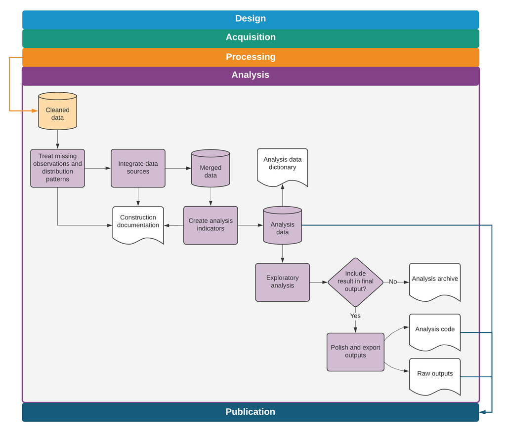

Data analysis tasks and outputs

# 7 Publishing reproducible research outputs

Publication typically involves many iterations of data, code, and code output files, with inputs from multiple collaborators. This process can quickly become unwieldy. It is in nobody’s interest for a skilled and busy researcher to spend days re-numbering figures, tables, or references (and it can take days) when a reasonable amount of up-front effort can automate the task. Similarly, simultaneous collaboration should not involve the repetitive and error-prone task of manually resolving sets of tracked-changes documents with conflicting edits. Furthermore, for most development data projects, completing a research output is not the end of the task. Academic journals increasingly require reproducibility packages containing the data, code, and supporting materials needed to recreate the results. DIME requires reproducibility packages for all published outputs. Replication materials represent an intellectual contribution in their own right, because they enable others to learn from your process and better understand the results you have obtained. If you have organized your analysis process according to the general principles outlined in earlier chapters, publication will not require substantial reorganization of the work you have already done. Hence, publication is the conclusion of the system of transparent, reproducible, and credible research we introduced from the very first chapter of this book.

In this chapter, we suggest tools and workflows for efficiently managing collaboration on research and policy outputs and ensuring reproducible results. The first section discusses how to use dynamic documents to collaborate on writing. The second section covers how to prepare and publish original data, an important research contribution in its own right. The third section provides guidelines for preparing functional and informative reproducibility packages. In all cases, we note that technology is rapidly evolving and that specific tools noted here may not remain cutting-edge, but the core principles involved in publication and transparency will endure.

## Publishing research papers and reports

% collaborating is easier with dynamic documents Development research is increasingly a collaborative effort. This reflects changes in the economics discipline overall: the number of sole-authored research outputs is decreasing, and the majority of recent papers in top journals have three or more authors.[^255] As a consequence, documents typically pass back and forth between several writers before they are ready for publication or release. As in all other stages of the research process, effective collaboration requires the adoption of tools and practices that enable version control and simultaneous contributions. This book, for example, was written in LaTeX and managed on GitHub.[^256] As we outlined in the previous chapter, **dynamic documents** are a way to simplify writing workflows: updates to code outputs that appear in these documents, such as tables and figures, can be passed in to the final research output in a single click, rather than copy-and-pasted or otherwise handled individually. Managing the writing process in this way improves organization and reduces error, such that there is no risk of materials being compiled with out-of-date results, or of completed work being lost or redundant.

### Using LaTeX for written documents

As we discussed in Chapter 6, the most widely used software for dynamically managing formal manuscripts and policy outputs is LaTeX. It is also becoming more popular for shorter documents, such as policy briefs, with the proliferation of skills and templates for these kinds of products. LaTeX uses explicit references to the file path of each input (such as tables and figures), which are reloaded from these locations every time the final document is compiled. This is not possible by default in, for example, Microsoft Word. There, you have to copy and paste each object whenever tables, graphs, or other inputs are updated. As time goes on, it becomes increasingly likely that a mistake will be made or something will be missed. In LaTeX, instead of writing in a “what-you-see-is-what-you-get” mode as you do in Word, you write plain text in a `.tex` file, interlaced with coded instructions formatting the document and linking to exhibits (similar to HTML). LaTeX manages tables and figures dynamically and includes commands for simple markup like font styles, paragraph formatting, section headers and the like. It includes special controls for footnotes and endnotes, mathematical notation, and bibliography preparation. It also allows publishers to apply global styles and templates to already-written material, reformatting entire documents in house styles with only a few keystrokes.

While LaTeX *can* produce complex formatting, this is rarely needed for academic publishing, as academic manuscripts will usually be reformatted based on the style of the publisher. (By contrast, policy and other self-produced documents may desire extensive typesetting and investments in custom templates and formatting.) In academia at least, it’s rarely worth the investment to go beyond basic LaTeX tools: the title page, sections and subsections, figures and tables, mathematical equations, bolding and italics, footnotes and endnotes, and, last but not least, references and citations. We acknowledge that many of these functionalities including dynamic updating of some outputs can be achieved in Microsoft Word through the use of plugins and careful workflows. If you can maintain such a workflow, that is an acceptable approach to the same problem, but we recommend moving towards adoption of LaTeX when it is possible for you and your team.

One of the most important tools available in LaTeX is the BibTeX citation and bibliography manager.[^257] BibTeX keeps all the references you might use in a `.bib` file, then references them using a simple command typed directly in the document. Specifically, LaTeX inserts references in text using the `cite` command. Once this is written, LaTeX automatically pulls all the citations into text and creates a complete bibliography based on the citations you used whenever you compile the document. The system allows you to specify exactly how references should be displayed in text (such as superscripts, inline references, etc.) as well as how the bibliography should be styled and in what order (such as Chicago, MLA, Harvard, or other common styles). The same principles that apply to figures and tables are therefore applied here: You can make changes to the references in one place (the `.bib` file), and then everywhere they are used they are updated correctly with one process. BibTeX is so widely used that it is natively integrated in Google Scholar. Since different publishers have different requirements, it is quite useful to be able to adapt this and other formatting very quickly, including through using publisher-supplied templates where available.

Because it follows a standard code format, LaTeX has one more useful trick: you can convert the raw document into Word or a number of other formats using utilities such as `pandoc`.[^258] Even though conversion to Word is required for a number of academic publishers and can even be preferred for some policy outputs, we still recommend using LaTeX to prepare these when possible. You should export to Word only at the final stage, when submitting materials. You can also use a CSL (Citation Styles Library) file[^259] for nearly any journal and have it applied automatically in this process. Therefore, even in the case where you are required to provide `.docx} versions of materials to others, or tracked-changes versions, you can create them effortlessly from a LaTeX document, then use external tools like Word’s compare feature to generate integrated track-changes versions when needed.

### Getting started with LaTeX as a team

Getting used to LaTeX can be challenging, but the control it offers over the writing process is invaluable. Because it is written in a plain text file format, `.tex` can be version-controlled using Git. This makes it possible to manage contributions and version histories using the same system we recommend for data work. DIME Analytics has created a variety of templates and resources that you can adapt for your own team.[^260] Integrated editing and compiling tools like TeXStudio[^261] and *atom-latex*[^262] offer the most flexibility to work with LaTeX in teams.

Although ultimately worth it, setting up LaTeX environments locally is not always simple, particularly if you are new to working with plain text code and file management. This is because LaTeX requires that all formatting be done in its special code language, and it is not always informative when you do something wrong. This can be off-putting very quickly for people who simply want to get to writing, and staff not used to programming may not easily acquire the necessary knowledge.

Cloud-based implementations of LaTeX can make it easier for your team to use LaTeX without all members having to invest in new skills or set up matching software environments, and can be particularly useful for first forays into LaTeX writing. One example of this is Overleaf.[^263] Most such sites offer a subscription feature with useful extensions and various sharing permissions, and some offer free-to-use versions with basic tools that are sufficient for a broad variety of applications, up to and including writing a complete academic paper with coauthors.

Cloud-based implementations of LaTeX have several advantageous features for teams compared to classic desktop installations. First, since they are completely hosted online, they avoid the inevitable troubleshooting required to set up a LaTeX installation on various personal computers run by the different members of a team. Second, they typically maintain a single, continuously synced, master copy of the document so that different writers do not create conflicted or out-of-sync copies, or need to deal with Git themselves to maintain that sync. Third, they typically allow collaborators to edit documents simultaneously, though different services vary the number of collaborators and documents allowed at each tier. Fourth, some implementations provide a “rich text” editor that behaves pretty similarly to familiar tools like Word, so that collaborators can write text directly into the document without worrying too much about the underlying LaTeX coding. Cloud services also usually offer a convenient selection of templates so it is easy to start up a project and see results right away without needing to know a lot of the code that controls document formatting.

Cloud-based implementations of LaTeX also have disadvantages. There is still some up-front learning required, unless you’re using the rich text editor. Continuous access to the internet is necessary, and updating figures and tables requires a bulk file upload that is tough to automate. Although some services offer ways to track changes and even to integrate a git workflow, doing version control is not as straightforward as using git locally. Finally, they also vary dramatically in their ability to integrate with file systems where you store your code and code outputs, and so you will need to practice an integrated workflow depending what is available to you. Some teams adopt cloud-based tools as a permanent solution, though our recommendation is to eventually shift to local editing and compiling using tools such as TexStudio and code editors like Atom.

## Preparing research data for publication

While we have focused so far on written materials, you must also consider how you will publish the data used in your research. The open science community at large sees data publication both as a citable output and as a necessary transparency measure. Fortunately, it is a conceptually simple task to produce and catalog the required materials. You should be prepared to catalog two separate collections. First, you should catalog the clean data with all variables corresponding directly to fields in the original dataset or data collection instrument (this will not be necessary if you are working with secondary data that was not produced by your team, but you will still need to carefully explain the process of acquiring this data). If you follow the steps outlined in Chapter 5, when you get to the publication stage you will have a cleaned data set and supporting documentation ready.

Second, you should separately catalog the analysis dataset used for the research output you are publishing. This is typically included in the replication package for the research output, and should assume that another researcher is starting work with only the published clean data in hand.[^264] The package should also include the data construction scripts that create transformed and derived indicators, project-specific information such as treatment assignment and other indicators generated directly by the research team (another example is constructed record linkages). If you followed the workflow recommended in Chapter 6, by the time you reach publication stage you will already have all necessary files and documentation at hand.

### De-identifying data for publication

Before publishing data, you should carefully perform a **final de-identification**. The objective of de-identification is to reduce the risk of disclosing confidential information in the published dataset. If you are following the workflow outlined in this book, you should have already removed direct identifiers as a first step after acquiring the data (see the discussion of initial de-identification in Chapter 5). For the final de-identification, you should additionally remove indirect identifiers, and assess the statistical disclosure risk of your data.[^265] Unlike direct identifiers, for which a link (or lack thereof) to public information is verifiable, indirect identifiers require an assessment of the likelihood that an individual can be singled out in the data and then linked to public information using combinations of available data. For example, seemingly innocuous variables such as US zip code, gender, and date of birth uniquely identify approximately 87% of the US population.[^266] In development data, information such as the size of a household, the ages and marital statuses of the household members, and the types of work or schooling they engage in may be more than enough to identify a person or family from a sufficiently small group.

A number of tools have been developed to help researchers de-identify data. At this stage, the World Bank’s `sdcMicro` tool,[^267] has a useful feature that allows you to assess the uniqueness of the records in your data. It produces simple measures of the identifiability of records from the combination of potentially indirectly identifying variables, and allows you to apply common information masking algorithms, such as binning, top-coding, and jittering data prior to release. You should determine how sensitive your results are to these transformations; it may be the case that masked data cannot be used for your reproducibility package.

There will almost always be a trade-off between accuracy and privacy. For publicly disclosed data, you should favor privacy. Stripping identifying variables from a dataset may not be sufficient to protect respondent privacy, due to the risk of re-identification. One solution is to add noise to data, as the U.S. Census Bureau has proposed.[^268] This makes the trade-off between data accuracy and privacy explicit. But there are not, as of yet, established norms for such “differential privacy” approaches: most approaches fundamentally rely on judging “how harmful” information disclosure would be. The fact remains that there is always a balance between information release (and therefore transparency) and privacy protection, and that you should engage with it actively and explicitly. The best thing you can do is make a complete record of the steps that have been taken so that the process can be reviewed, revised, and updated as necessary.

Removing variables results in loss of information, so the de-identification process requires careful assessment of the potential risk to the individual that could be caused by disclosure of their identity or personal information. This will vary widely depending on the types of information you are collecting and the overall vulnerability of the population. In extreme cases, where the population is highly vulnerable and combinations of information are highly specific, you may not be able to publicly release any data at all. You will still be expected to catalog and cite your data, even if you cannot release it publicly. In practice, this may mean publishing only a catalog entry providing information about the contents of the datasets and how future users might request permission to access them (even if you are not the person to grant that permission). In some cases, it may be possible to release the dataset but embargoing specific variables that are required for the analysis but cannot be released publicly. It may be necessary to grant access to the embargoed data for specific purposes, such as a computational reproducibility check required for publication, if done under careful data security protocols and approved by an IRB.

### Publishing research datasets

Publicly documenting all original data acquired as part of a research project is an important contribution in its own right. Cataloging and/or archiving original datasets is a significant contribution in addition to any publication of analysis results.[^269] Publicly releasing data allows other researchers to validate the mechanical construction of your results, investigate what other results might be obtained from the same population, and test alternative approaches or answer other questions. This fosters collaboration and may enable researchers to explore variables and questions that you do not have time to focus on otherwise.

The first step toward data publication is choosing the platform where you will publish your data. A variety of options exist; it is important to choose one that allows you to obtain a digital object identifier (DOI) for the location of your data (even if its URL changes), and a formal citation for your data, so you can reference it in other research outputs.[^270] Two common platforms for development data are the World Bank’s Development Data Hub and Harvard University’s Dataverse. The World Bank’s Development Data Hub[^271] includes a Microdata Catalog[^272] and a Geospatial Catalog, where researchers can publish data and documentation for their projects.[^273] The Harvard Dataverse publishes both data and code, and its Datahub for Field Experiments in Economics and Public Policy[^274] is especially relevant for impact evaluations. Both the World Bank Microdata Catalog and the Harvard Dataverse create data citations for deposited entries. DIME has its own collection of datasets in the Microdata Catalog, where data from our projects is published.[^275]

Once you have chosen a platform, you need to determine exactly what data you will publish. As mentioned earlier, there are typically two different types of data releases for a research project: complete (de-identified) original datasets and derivative datasets used for specific research outputs. Whether you can publish the original dataset depends on data ownership and licensing agreements. If the data was acquired through a survey that was contracted by the research team, the data most likely belongs to the research team, and therefore the team has publication rights for both the original and derivative data. If data was acquired from a partner through a licensing agreement, the terms of the license will determine publication rights. These datasets should match the survey instrument or source documentation as closely as possible, and should not include indicators constructed by the research team. Even if you do not have rights to publish the original data, you can typically publish derivative datasets prepared by the research team. These datasets usually contain only the constructed indicators and associated documentation, and should also be included in the replication package.

When publishing data, you will decide how the data may be used and what license you will assign to it. Make sure you understand the rights associated with any data release and communicate them to its future users. Material without a license may never be reused. You should prefer to offer a license that is explicit and details whether and how specific individuals may access the data. Terms of use available in the World Bank Microdata Catalog include, in order of increasing restrictiveness: *open access*, *direct access*, and *licensed access*.[^276] *Open access* data is freely available to anyone, and simply requires attribution. *Direct access* data is available to registered users who agree to use the data for statistical and scientific research purposes only, to cite the data appropriately, and not to attempt to identify respondents or data providers or link the data to other datasets that could allow for re-identification. *Licensed access* data is restricted to users who submit a documented application detailing how they will use the data and then sign a formal agreement governing data use. The user must be acting on behalf of an organization, which will be held responsible in the case of any misconduct.

Published data should be released in a widely recognized format. While software-specific datasets are acceptable accompaniments to the code (since those precise materials are probably necessary), you should also consider releasing datasets in plain text formats such as CSV files with accompanying codebooks, since these can be used by any researcher. Additionally, you should also release PDF or code versions of the data collection instrument or survey questionnaire so that readers can understand which data components are collected directly in the field and which are derived. With your analysis dataset, you should also release the code that constructs any derived measures from the clean dataset, so that others can learn from your work and adapt it as they like.

## Publishing a reproducible research package

Major journals now often require that you provide both the data and code required to recreate your results. Some even require being able to reproduce the results themselves before they will approve a paper for publication.[^277] If you are producing a policy output, such as an open policy analysis[^278] or some other type of material,[^279] you may also want to make your materials publicly reproducible. Even if your work is only meant for use inside your organization, having a final set of production materials is still a valuable output. This set of materials, taken together, is often referred to as a **reproducibility package**. If you have followed the workflows described in this book, preparing the replication package will only require a small amount of extra work. If not, creating this package may take some time. When the replication package is completed, whoever downloads it should be able to understand how your code produces results from your data and be able to reproduce them exactly by executing the included master script.

### Organizing code for reproducibility

Before releasing your code, you should edit it for content and clarity just as if it were written material. The purpose of releasing code is to allow others to understand exactly what you have done in order to obtain your results, and enable them to apply similar methods in future projects. Other researchers should be able to reproduce individual portions of your analysis by making only small adjustments to your code. In either a scripts folder or in the root directory, you should include a master script that allows someone else to run the entire project and re-create all raw code outputs by changing only a single line of code: the one setting the directory path. The code should both be functional and readable, through the use of a clear structure and extensive commenting. Code is often not written this way when it is first prepared, so it is important for you to review the content and organization so that a new reader can figure out what your code should do and how it does it. Making code clean and readable is often where you need to invest time prior to releasing your reproducibility package.

DIME requires all academic outputs to successfully pass a computational reproducibility check before being submitted for publication. We have adopted several practices and requirements to support the production of high-quality reproducibility packages. The materials for these practices are publicly available, so you can use them to check the reproducibility of your own work. This reproducibility check is initiated by submitting the Reproducibility Package Checklist.[^280] DIME projects are required to organize code with a master script, to facilitate handovers across team members and make the computational reproducibility check a one-click exercise. Compliance with these and other coding standards at DIME is monitored through quarterly peer code review rounds, which allows research assistants to improve their code and documentation as it is written, rather than revisiting it in a rush near publication time. DIME projects are also expected to use Git and GitHub to document project work and collaboration, and to keep the main branch up-to-date as a working edition.

Before publicly releasing a reproducibility package, it is essential to make sure that the code runs identically on your individual setup compared to a fresh installation of your software. To ensure that your code will run completely on a new computer, you must install any required user-written commands in the master script (for example, in Stata using `ssc install` or `net install` and in R adding code that gives users the option to install packages, including selecting a specific version of the package if necessary[^281] ). In many cases you can even directly provide the underlying code for any user-installed packages that are needed to ensure forward-compatibility. Make sure system settings like software version and memory settings are defined. The `ieboilstart` command in `ietoolkit` defines and applies these settings for a chosen Stata version.[^282]

Finally, make sure that code inputs and outputs are clearly identified. A new user should, for example, be able to easily find and quickly recreate any files generated by the code. It should be easy to locate an output in the code, and it should be easy to correspond code to its outputs. Code should be broken down into separate scripts as much as possible to minimize searching through long files. Someone reading the code should fairly easily be able to figure out what state the program will be in at any point without scrolling through hundreds of lines; similarly, they should not have to look in different files or faraway sections of code to make changes to outputs. Each file should be an understandable, independent selection of related processes. Readers should also be able to easily map all the outputs of the code to where they appear in the associated published material, so you must ensure ensure that the raw components of figures or tables are clearly identified. Documentation in the master script is often used to indicate this information. For example, code outputs should clearly correspond by name to an exhibit in the paper, and vice versa. (Supplying a compiling LaTeX document can support this.) Code and code outputs which are not used in the final paper should be removed from the final replication package, but still archived for transparency.

### Releasing a reproducibility package

Once your replication package is prepared for public release, you need to find a place to publish your materials.[^283] At the time of writing, there is no consensus on the best solution for publishing code, and there are a variety of archives and storage providers that cater to different needs. The technologies available are likely to change dramatically over the next few years; the specific solutions we mention here highlight some current approaches as well as their strengths and weaknesses.

Features to look for in a platform to release reproducibility packages include: the possibility to store data and documentation as well as code, the creation of a static copy of its content, that cannot be changed or removed, and the assignment of a permanent digital object identifier (DOI) link. Unlike data, code usually has few external constraints to publication. The research team owns the code in almost all cases, and code is unlikely to contain identifying information (though you must verify that it does not). Publishing code also requires assigning a license to it; most code publishers offer permissive licensing options. If you do not provide a license, no one can reuse your code. It is common to only require attribution and citation for code reuse, without putting any barriers or restrictions to accessing the code.

One option for creating and releasing a reproducibility package is GitHub. Making a public GitHub repository is completely free. It can hold any file types, provide a structured, compressed download of your whole project, and allow others to look at alternate versions or histories easily. It is straightforward to simply upload a fixed directory to GitHub, apply a sharing license, and obtain a URL for the whole package. There is a strict size restriction of 100MB per file and a restriction of 100GB on the size of the repository as a whole, so larger projects will need alternative solutions. However, GitHub is not the ideal platform on which to `publish` reproducibility packages. It is built to version control code, and to facilitate collaboration on it. It is not an archive, meaning that it does not guarantee the permanence of uploaded materials or the access URL, and it does not manage citations or non-code licenses by default. One suggestion is to combine GitHub with the Open Science Framework,[^284] as OSF can easily link to and import material from GitHub and apply a permanent URL, DOI, formal citation, general license, and archival services to it.

Other options include the Harvard Dataverse[^285] and ResearchGate.[^286] Any of these archival services is acceptable – the main requirement is that the system can handle the structured directory that you are submitting, and that it can provide a stable URL for your project and report exactly what, if any, modifications you have made since initial publication. You can even combine more than one tool if you prefer, as long as they clearly reference each other. For example, one could publish code and the corresponding license on GitHub and point to data published on the World Bank Microdata Catalog. Emerging technologies such as the “containerization” approach of CodeOcean[^287] offer to store both code and data in one repository, and also provide an online workspace in which others can execute and modify your code without having to download your tools and match your local environment. This is particularly useful over time, as packages and other underlying software may have changed since publication.

In addition to code and data, you may also want to release an author’s copy or preprint of the article itself along with these materials. Check with your publisher before doing so; not all journals will accept material that has been publicly released before its formal publication date, although, in most development research fields, the release of working papers is a fairly common practice. This can be done on a number of preprint websites, many of which are topic-specific. You can also use GitHub or OSF and link to the PDF file directly through your personal website or whatever medium you are sharing the preprint. We recommend against using file sharing services such as Dropbox or Google Drive for this purpose, as their access is more restrictive, and organizations limit access to platforms other than the one officially adopted.

Finally, any reproducibility package should include an overview of its contents and instructions on how to recreate your outputs. This is typically done in the form of a README file. A good README will guide the reader through all the items included in the package. Fortunately, a very good template for such documents is offered by a consortium of social science data editors.[^288]

## Looking ahead

This chapter described the culmination of all the efforts in data acquisition, cleaning, processing, and analyzing – the production of materials to share with the world that answer a scientific or policy question in a way that has never been done before. The figure included in this chapter provides an overview of all the outputs created by this stage. Making sure that everything you discovered and created is as broadly available and as easy to use as possible is the last step in producing scientific evidence from original data. This is the purpose of all the rigor, organization, and documentation we encourage and detail at every step of the process: since all your research materials are continuously organized, shareable, secure, documented, and readable, they are both valuable to you and others and easy to provide access to.

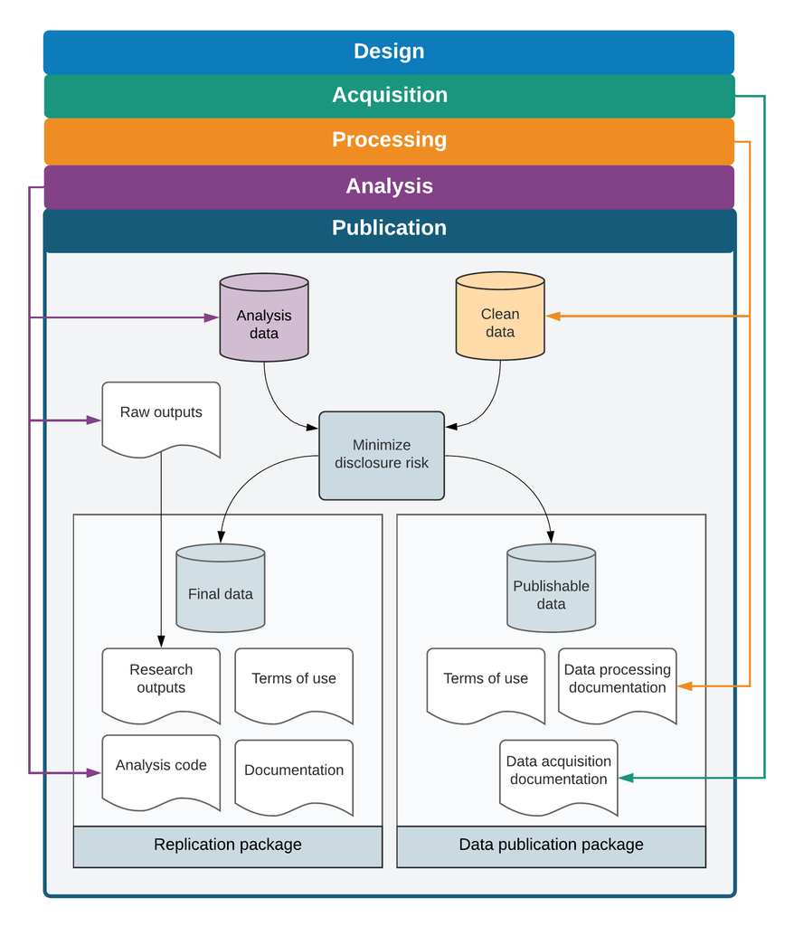

# Bibliography

Abowd, John M. 2018. “The U.S. Census Bureau Adopts Differential Privacy.” In *Proceedings of the 24th Acm Sigkdd International Conference on Knowledge Discovery & Data Mining*, 2867–7. ACM.

Adjognon, Guigonan Serge, Daan van Soest, and Jonas Guthoff. 2019. *Reducing Hunger with Payments for Ecosystem Services (Pes): Experimental Evidence from Burkina Faso*. The World Bank.

Alix-Garcia, Jennifer M, Katharine RE Sims, Victor Hugo Orozco-Olvera, Laura Costica, Jorge David Fernandez Medina, Sofia Romo-Monroy, and Stefano Pagiola. 2019. *Can Environmental Cash Transfers Reduce Deforestation and Improve Social Outcomes? A Regression Discontinuity Analysis of Mexico’s National Program (2011–2014)*. The World Bank.

Angrist, Joshua D, and Jörn-Steffen Pischke. 2008. *Mostly Harmless Econometrics: An Empiricist’s Companion*. Princeton University Press.

———. 2010. “The Credibility Revolution in Empirical Economics: How Better Research Design Is Taking the Con Out of Econometrics.” *Journal of Economic Perspectives* 24 (2): 3–30.

Athey, Susan, and Guido W Imbens. 2017. “The Econometrics of Randomized Experiments.” *Handbook of Economic Field Experiments* 1: 73–140.

Baldwin, Kate, Shylock Muyengwa, and Eric Mvukiyehe. 2017. *Reforming Village-Level Governance via Horizontal Pressure: Evidence from an Experiment in Zimbabwe*. The World Bank.

Baldwin, Kate, and Eric Mvukiyehe. 2015. “Elections and Collective Action: Evidence from Changes in Traditional Institutions in Liberia.” *World Politics* 67 (4): 690–725.

Banerjee, Abhijit, Eliana La Ferrara, and Victor Orozco. 2019. “Entertainment, Education, and Attitudes Toward Domestic Violence.” In *AEA Papers and Proceedings*, 109:133–37.

Bedoya, Guadalupe, Aidan Coville, Johannes Haushofer, Mohammad Razaq Isaqzadeh, and Jeremy Shapiro. 2019. *No Household Left Behind: Afghanistan Targeting the Ultra Poor Impact Evaluation*. The World Bank.

Begg, Colin, Mildred Cho, Susan Eastwood, Richard Horton, David Moher, Ingram Olkin, Roy Pitkin, et al. 1996. “Improving the Quality of Reporting of Randomized Controlled Trials: The CONSORT Statement.” *JAMA* 276 (8): 637–39.

Benhassine, Najy, David McKenzie, Victor Pouliquen, and Massimiliano Santini. 2018. “Does Inducing Informal Firms to Formalize Make Sense? Experimental Evidence from Benin.” *Journal of Public Economics* 157: 1–14.

Benschop, Thijs, Cathrine Machingauta, and Matthew Welch. 2019. “Statistical Disclosure Control: A Practice Guide.”

Bertrand, Marianne, Bruno Crépon, Alicia Marguerie, and Patrick Premand. 2017. *Contemporaneous and Post-Program Impacts of a Public Works Program: Evidence from côte d’Ivoire*. World Bank.

Bierer, Barbara E, Mark Barnes, and Holly Fernandez Lynch. 2017. “Revised ‘Common Rule’ Shapes Protections for Research Participants.”

Bjärkefur, Kristoffer, Luı́za Cardoso de Andrade, and Benjamin Daniels. 2020. “Iefieldkit: Commands for Primary Data Collection and Cleaning.” *The Stata Journal* 20 (4): 892–915.

Calderon, Gabriela, Leonardo Iacovone, and Laura Juarez. 2017. “Opportunity Versus Necessity: Understanding the Heterogeneity of Female Micro-Entrepreneurs.” *The World Bank Economic Review* 30 (Supplement_1): S86–S96.

Camerer, Colin F, Anna Dreber, Eskil Forsell, Teck-Hua Ho, Jürgen Huber, Magnus Johannesson, Michael Kirchler, et al. 2016. “Evaluating Replicability of Laboratory Experiments in Economics.” *Science* 351 (6280): 1433–6.

Carril, Alvaro. 2017. “Dealing with Misfits in Random Treatment Assignment.” *The Stata Journal* 17 (3): 652–67.

Chang, Andrew C, and Phillip Li. 2015. “Is Economics Research Replicable? Sixty Published Papers from Thirteen Journals Say ’Usually Not’.” *Available at SSRN 2669564*.

Christensen, Garret, and Edward Miguel. 2018. “Transparency, Reproducibility, and the Credibility of Economics Research.” *Journal of Economic Literature* 56 (3): 920–80.

Coville, Aidan, Vincenzo Di Maro, Felipe Alexander Dunsch, and Siegfried Zottel. 2019. *The Nollywood Nudge: An Entertaining Approach to Saving*. The World Bank.

Cunningham, Scott. 2018. “Causal Inference: The Mixtape.” Manuscript.

Cusolito, Ana Paula, Ernest Dautovic, and David McKenzie. 2018. *Can Government Intervention Make Firms More Investment-Ready? A Randomized Experiment in the Western Balkans*. The World Bank.

Daniels, Benjamin. 2019. “OUTWRITE: Stata Module to Consolidate Multiple Regressions and Export the Results to a. Xlsx,. Xls,. Csv, or. Tex File.”

Daniels, Benjamin, Amy Dolinger, Guadalupe Bedoya, Khama Rogo, Ana Goicoechea, Jorge Coarasa, Francis Wafula, Njeri Mwaura, Redemptar Kimeu, and Jishnu Das. 2017. “Use of Standardised Patients to Assess Quality of Healthcare in Nairobi, Kenya: A Pilot, Cross-Sectional Study with International Comparisons.” *BMJ Global Health* 2 (2): e000333.

De Andrade, Gustavo Henrique, Miriam Bruhn, and David McKenzie. 2013. *A Helping Hand or the Long Arm of the Law? Experimental Evidence on What Governments Can Do to Formalize Firms*. The World Bank.

Duflo, Esther, Abhijit Banerjee, Amy Finkelstein, Lawrence F Katz, Benjamin A Olken, and Anja Sautmann. 2020. “In Praise of Moderation: Suggestions for the Scope and Use of Pre-Analysis Plans for RCTs in Economics.” National Bureau of Economic Research.

Duflo, Esther, Rachel Glennerster, and Michael Kremer. 2007. “Using Randomization in Development Economics Research: A Toolkit.” *Handbook of Development Economics* 4: 3895–3962.

Duvendack, Maren, Richard Palmer-Jones, and W Robert Reed. 2017. “What Is Meant by ‘Replication’ and Why Does It Encounter Resistance in Economics?” *American Economic Review* 107 (5): 46–51.

Fernandes, Ana M, Russell Hillberry, and Alejandra Mendoza Alcántara. 2015. *Trade Effects of Customs Reform: Evidence from Albania*. The World Bank.

Fernandes, Ana M, Russell Hillberry, and Alejandra Mendoza Alcantara. 2017. *An Evaluation of Border Management Reforms in a Technical Agency*. The World Bank.

Gelman, Andrew, and Eric Loken. 2013. “The Garden of Forking Paths: Why Multiple Comparisons Can Be a Problem, Even When There Is No ‘Fishing Expedition’ or ‘P-Hacking’ and the Research Hypothesis Was Posited Ahead of Time.” *Department of Statistics, Columbia University*.

Gibson, Mike, and Anja Sautmann. 2020. “Introduction to Randomized Evaluations.” https://www.povertyactionlab.org/resource/introduction-randomized-evaluations.

Glewwe, Paul, and Margaret E Grosh. 2000. *Designing Household Survey Questionnaires for Developing Countries: Lessons from 15 Years of the Living Standards Measurement Study*. World Bank.

Goldstein, Markus, Kenneth Houngbedji, Florence Kondylis, Michael O’Sullivan, and Harris Selod. 2015. *Formalizing Rural Land Rights in West Africa: Early Evidence from a Randomized Impact Evaluation in Benin*. The World Bank.

Haghish, E. F. 2016. “Markdoc: Literate Programming in Stata.” *Stata Journal* 16 (4): 964–988(25). http://www.stata-journal.com/article.html?article=pr0064.

Hamermesh, Daniel S. 2007. “Replication in Economics.” *Canadian Journal of Economics/Revue Canadienne d’économique* 40 (3): 715–33.

Healy, Kieran. 2018. *Data Visualization: A Practical Introduction*. Princeton University Press.

Hlavac, Marek. 2015. “Stargazer: Beautiful LATEX, HTML and ASCII Tables from R Statistical Output.”

Hoces de la Guardia, Fernando, Sean Grant, and Edward Miguel. 2018. “A Framework for Open Policy Analysis.” *Science and Public Policy*.

Ioannidis, John PA. 2005. “Why Most Published Research Findings Are False.” *PLoS Medicine* 2 (8): e124.

Ioannidis, John PA, Tom D Stanley, and Hristos Doucouliagos. 2017. “The Power of Bias in Economics Research.” *The Economic Journal*.

Jann, B. 2016. “Creating Latex Documents from Within Stata Using Texdoc.” *Stata Journal* 16 (2): 245–263(19). http://www.stata-journal.com/article.html?article=pr0062.

———. 2017. “Creating Html or Markdown Documents from Within Stata Using Webdoc.” *Stata Journal* 17 (1): 3–38(36). http://www.stata-journal.com/article.html?article=pr0065.

Jann, Benn. 2005. “Making Regression Tables from Stored Estimates.” *Stata Journal* 5 (3): 288–308(21). http://www.stata-journal.com/article.html?article=st0085.

———. 2007. “Making Regression Tables Simplified.” *Stata Journal* 7 (2): 227–244(18). http://www.stata-journal.com/article.html?article=st0085_1.

Jones, Maria Ruth, Florence Kondylis, John Ashton Loeser, and Jeremy Magruder. 2019. *Factor Market Failures and the Adoption of Irrigation in Rwanda*. The World Bank.

Keating, Joseph, Andrea Locatelli, Andemariam Gebremichael, Tewolde Ghebremeskel, Jacob Mufunda, Selam Mihreteab, Daniel Berhane, and Pedro Carneiro. 2011. “Evaluating Indoor Residual Spray for Reducing Malaria Infection Prevalence in Eritrea: Results from a Community Randomized Control Trial.” *Acta Tropica* 119 (2-3): 107–13.

Kerr, Norbert L. 1998. “HARKing: Hypothesizing After the Results Are Known.” *Personality and Social Psychology Review* 2 (3): 196–217.

Kondylis, Florence, Arianna Legovini, Kate Vyborny, Astrid Maria Theresia Zwager, and Luiza Cardoso De Andrade. 2020. “Demand for Safe Spaces: Avoiding Harassment and Stigma.” *World Bank Policy Research Working Paper*, no. 9269.

Kondylis, Florence, Valerie Mueller, Glenn Sheriff, and Siyao Zhu. 2016. “Do Female Instructors Reduce Gender Bias in Diffusion of Sustainable Land Management Techniques? Experimental Evidence from Mozambique.” *World Development* 78: 436–49.

Kondylis, Florence, Valerie Mueller, and Siyao Zhu. 2015. “Measuring Agricultural Knowledge and Adoption.” *Agricultural Economics* 46 (3): 449–62.

Kondylis, Florence, and Mattea Stein. 2018. *The Speed of Justice*. The World Bank.

Kopka, Helmut, and Patrick W Daly. 1995. “A Guide to LATEX.” *IEEE Multimedia* 2: 473–80.

Kuld, Lukas, and John O’Hagan. 2017. “The Trend of Increasing Co-Authorship in Economics: New Evidence.”

Legovini, Arianna, Guigonan Serge Adjognon, Guadalupe Bedoya Arguelles, Theophile Bougna Lonla, Kayleigh Bierman Campbell, Paul J. Christian, Aidan Coville, et al. 2019. “Science for Impact: Better Evidence for Better Decisions -– the DIME Experience.” World Bank Group. http://documents.worldbank.org/curated/en/942491550779087507/Science-for-Impact-Better-Evidence-for-Better-Decisions-The-Dime-Experience.

Legovini, Arianna, Vincenzo Di Maro, and Caio Piza. 2015. *Impact Evaluation Helps Deliver Development Projects*. The World Bank.

McCullough, Bruce D, Kerry Anne McGeary, and Teresa D Harrison. 2008. “Do Economics Journal Archives Promote Replicable Research?” *Canadian Journal of Economics/Revue Canadienne d’économique* 41 (4): 1406–20.

McGovern, Mark E. 2012. “A Practical Introduction to Stata.” PGDA Working Papers 9412. Program on the Global Demography of Aging. https://ideas.repec.org/p/gdm/wpaper/9412.html.

Nosek, Brian A, George Alter, George C Banks, Denny Borsboom, Sara D Bowman, Steven J Breckler, Stuart Buck, et al. 2015. “Promoting an Open Research Culture.” *Science* 348 (6242): 1422–5.

Nosek, Brian A, Charles R Ebersole, Alexander C DeHaven, and David T Mellor. 2018. “The Preregistration Revolution.” *Proceedings of the National Academy of Sciences* 115 (11): 2600–2606.

Olken, Benjamin A. 2015. “Promises and Perils of Pre-Analysis Plans.” *Journal of Economic Perspectives* 29 (3): 61–80.

Orozco, Valerie, Christophe Bontemps, Elise Maigne, Virginie Piguet, Annie Hofstetter, Anne Lacroix, Fabrice Levert, Jean-Marc Rousselle, and others. 2018. “How to Make a Pie? Reproducible Research for Empirical Economics & Econometrics.” *Toulouse School of Economics Working Paper* 933.

Ozier, Owen. 2019. *Replication Redux: The Reproducibility Crisis and the Case of Deworming*. The World Bank.

Özler, Berk, Lia CH Fernald, Patricia Kariger, Christin McConnell, Michelle Neuman, and Eduardo Fraga. 2016. *Combining Preschool Teacher Training with Parenting Education: A Cluster-Randomized Controlled Trial*. The World Bank.

Pradhan, Menno, Sally A Brinkman, Amanda Beatty, Amelia Maika, Elan Satriawan, Joppe de Ree, and Amer Hasan. 2013. “Evaluating a Community-Based Early Childhood Education and Development Program in Indonesia: Study Protocol for a Pragmatic Cluster Randomized Controlled Trial with Supplementary Matched Control Group.” *Trials* 14 (1): 259.

Prennushi, Giovanna, and Abhishek Gupta. 2014. *Women’s Empowerment and Socio-Economic Outcomes: Impacts of the Andhra Pradesh Rural Poverty Reduction Program*. The World Bank.

Rodriguez, G. 2017. “Literate Data Analysis with Stata and Markdown.” *Stata Journal* 17 (3): 600–618(19). http://www.stata-journal.com/article.html?article=pr0067.

Simmons, Joseph P, Leif D Nelson, and Uri Simonsohn. 2011. “False-Positive Psychology: Undisclosed Flexibility in Data Collection and Analysis Allows Presenting Anything as Significant.” *Psychological Science* 22 (11): 1359–66.

Simonsohn, Uri, Leif D Nelson, and Joseph P Simmons. 2014. “P-Curve: A Key to the File-Drawer.” *Journal of Experimental Psychology: General* 143 (2): 534.

Simonsohn, Uri, Joseph P Simmons, and Leif D Nelson. 2015. “Specification Curve: Descriptive and Inferential Statistics on All Reasonable Specifications.” *Available at SSRN 2694998*.

StataCorp, LLC. 2019. “Stata Statistical Software: Release 16. College Station, TX.”

Stodden, Victoria, Peixuan Guo, and Zhaokun Ma. 2013. “Toward Reproducible Computational Research: An Empirical Analysis of Data and Code Policy Adoption by Journals.” *PLoS One* 8 (6): e67111.

Swanson, Nicholas, Garret Christensen, Rebecca Littman, David Birke, Edward Miguel, Elizabeth Levy Paluck, and Zenan Wang. 2020. “Research Transparency Is on the Rise in Economics.” In *AEA Papers and Proceedings*, 110:61–65.

Sweeney, Latanya. 2000. “Simple Demographics Often Identify People Uniquely.” Working paper. *Carnegie Mellon University, Data Privacy*. http://dataprivacylab.org/projects/identifiability/.

Vilhuber, Lars. 2020. “Implementing Increased Transparency and Reproducibility in Economics.” Zenodo. https://doi.org/10.5281/zenodo.3911311.

Vilhuber, Lars, James Turrito, and Keesler Welch. 2020. “Report by the AEA Data Editor.” In *AEA Papers and Proceedings*, 110:764–75.

Wada, Roy. 2014. “OUTREG2: Stata Module to Arrange Regression Outputs into an Illustrative Table.”

Wafula, Francis, Amy Dolinger, Benjamin Daniels, Njeri Mwaura, Guadalupe Bedoya, Khama Rogo, Ana Goicoechea, Jishnu Das, and Bernard Olayo. 2017. “Examining the Quality of Medicines at Kenyan Healthcare Facilities: A Validation of an Alternative Post-Market Surveillance Model That Uses Standardized Patients.” *Drugs – Real World Outcomes* 4 (1): 53–63.

White, Matthew. 2016. “BCSTATS: Stata Module to Analyze Back Check (Field Audit) Data and Compare It to the Original Survey Data.”

Wicherts, Jelte M, Coosje LS Veldkamp, Hilde EM Augusteijn, Marjan Bakker, Robbie Van Aert, and Marcel ALM Van Assen. 2016. “Degrees of Freedom in Planning, Running, Analyzing, and Reporting Psychological Studies: A Checklist to Avoid P-Hacking.” *Frontiers in Psychology* 7: 1832.

Wickham, Hadley. 2016. *Ggplot2: Elegant Graphics for Data Analysis*. Springer-Verlag New York. https://ggplot2.tidyverse.org.

Wickham, Hadley, and Garrett Grolemund. 2017. *R for Data Science: Import, Tidy, Transform, Visualize, and Model Data*. 1st ed. O’Reilly Media, Inc.

Yishay, Ariel Ben, Maria Jones, Florence Kondylis, and Ahmed Mushfiq. 2016. *Are Gender Differences in Performance Innate or Socially Mediated?* The World Bank.

[^1]: Swanson et al. (2020)
[^2]: Vilhuber (2020)
[^3]: McCullough, McGeary, and Harrison (2008)
[^4]: https://blogs.worldbank.org/impactevaluations/more-replication-economics
[^5]: See Baldwin and Mvukiyehe (2015) for an example.
[^6]: Camerer et al. (2016)
[^7]: **Process standardization:** Agreement within a research team about how all tasks of a specific type will be approached.
[^8]: Hamermesh (2007)
[^9]: Ozier (2019)
[^10]: Chang and Li (2015)
[^11]: StataCorp, LLC (2019)
[^12]: See DIME Analytics Coding Standards: https://github.com/worldbank/dime-standards
[^13]: https://www.worldbank.org/en/research/dime
[^14]: Legovini, Di Maro, and Piza (2015)
[^15]: Legovini et al. (2019)
[^16]: Angrist and Pischke (2010), Ioannidis (2005)
[^17]: Ioannidis, Stanley, and Doucouliagos (2017)
[^18]: Simmons, Nelson, and Simonsohn (2011)
[^19]: Wicherts et al. (2016)
[^20]: Vilhuber, Turrito, and Welch (2020)
[^21]: More details on study registrations and links to additional resources can be found on the DIME Wiki: https://dimewiki.worldbank.org/Study_Registration
[^22]: Nosek et al. (2018)
[^23]: More details on how to pre-register your study and links to other resources can be found on the DIME Wiki: https://dimewiki.worldbank.org/Pre-Registration
[^24]: Kerr (1998)
[^25]: We recommend this checklist: https://blogs.worldbank.org/impactevaluations/a-pre-analysis-plan-checklist
[^26]: Gelman and Loken (2013)
[^27]: More details on how to prepare a pre-analysis plans and links to additional resources can be found on the DIME Wiki: https://dimewiki.worldbank.org/Pre-Analysis_Plan
[^28]: See Cusolito, Dautovic, and McKenzie (2018) for an example.
[^29]: Olken (2015)
[^30]: https://blogs.worldbank.org/impactevaluations/pre-analysis-plans-and-registered-reports-what-new-opinion-piece-does-and-doesnt
[^31]: See Bedoya et al. (2019) for an example.
[^32]: Duflo et al. (2020)
[^33]: More details on registered reports and links to additional resources can be found on the DIME Wiki: https://dimewiki.worldbank.org/Registered_Reports
[^34]: https://blogs.worldbank.org/impactevaluations/registered-reports-piloting-pre-results-review-process-journal-development-economics
[^35]: Simonsohn, Nelson, and Simmons (2014)
[^36]: See Coville et al. (2019) for an example.
[^37]: More details on research documentation and links to additional resources can be found on the DIME Wiki: https://dimewiki.worldbank.org/Research_Documentation
[^38]: Duvendack, Palmer-Jones, and Reed (2017)
[^39]: **Archival repository:** A third-party service for information storage that guarantees the permanent availability of current and prior versions of materials.
[^40]: https://osf.io
[^41]: https://github.com
[^42]: More details on how to use Git and GitHub and links to all DIME Analytics resources on best practices and how to get started can be found on the DIME Wiki: https://dimewiki.worldbank.org/Getting_started_with_GitHub
[^43]: See Yishay et al. (2016) for an example.
[^44]: **Original data:** A new dataset, as obtained and corrected, that becomes the functional basis for research work.
[^45]: Vilhuber, Turrito, and Welch (2020)
[^46]: For example, https://data.usaid.gov
[^47]: Details on how to document this type of material can be found at https://doi.org/10.5281/zenodo.4319999.
[^48]: https://microdata.worldbank.org
[^49]: https:/datacatalog.worldbank.org
[^50]: **Digital object identifier (DOI):** A permanent reference for electronic information that persistently updates to a new URL or other locations if the information is relocated.
[^51]: Christensen and Miguel (2018)
[^52]: More details and links to additional resources on how to make your research reproducible and prepare a reproducibility package can be found on the DIME Wiki: https://dimewiki.worldbank.org/Reproducible_Research. More details can also be found under Pillar 3 in the DIME Research Standards: https://github.com/worldbank/dime-standards.
[^53]: More details and links to best practices on topics related to data publication, such as de-identification and how to license published data, can be found on the DIME Wiki: https://dimewiki.worldbank.org/Publishing_Data. More details can also be found under Pillar 5 in the DIME Research Standards: https://github.com/worldbank/dime-standards
[^54]: Stodden, Guo, and Ma (2013)
[^55]: The DIME Analytics reproducibility checklist can be found in Pillar 3 of the DIME Research Standards at https://github.com/worldbank/dime-standards.
[^56]: Nosek et al. (2015)
[^57]: **Computational reproducibility:** The ability of another individual to reuse the same code and data and obtain the exact same results as yours.
[^58]: More details and links to additional resources on how to make your research reproducible and prepare a reproducibility package can be found on the DIME Wiki: https://dimewiki.worldbank.org/Reproducible_Research. More details can also be found under Pillar 3 in the DIME Research Standards: https://github.com/worldbank/dime-standards.
[^59]: https://blogs.worldbank.org/impactevaluations/what-development-economists-talk-about-when-they-talk-about-reproducibility
[^60]: Simonsohn, Simmons, and Nelson (2015)
[^61]: https://blogs.worldbank.org/opendata/making-analytics-reusable
[^62]: Read more details about back up strategies and other aspects of data storage on the DIME Wiki: https://dimewiki.worldbank.org/Data_Storage.
[^63]: More naming conventions and links to more resources can be found on the DIME Wiki: https://dimewiki.worldbank.org/Naming_Conventions.
[^64]: **Git:** A distributed version control system for collaborating on and tracking changes to code as it is written.
[^65]: Read more about how to install and use `ieboilstart` and how it can help you harmonize settings across users as much as possible in Stata on the DIME Wiki: https://dimewiki.worldbank.org/ieboilstart.
[^66]: https://www.rstudio.com
[^67]: More details on the benefits of external code editors and links to popular code editors can be found on the DIME Wiki: https://dimewiki.worldbank.org/Code_Editors.
[^68]: Read more about how to install and use `iefolder`, as well as find links to resources explaining the best practices this command build upon on the DIME Wiki: https://dimewiki.worldbank.org/iefolder.
[^69]: More details on DIME’s suggested data work folder structure and explanations of the best practices it is based on can be found on the DIME Wiki: https://dimewiki.worldbank.org/DataWork_Folder.
[^70]: Git only tracks files, so empty folders – which most folders are in the beginning of a project – are ignored if placeholder files are not used, leading to only parts of the folder structure being shared across the team. Read more about how to install and use `iegitaddmd` and how it can help you track empty folder in Git on the DIME Wiki: https://dimewiki.worldbank.org/Iegitaddmd.
[^71]: **Comments:** Code components that have no function to the computer, but describe in plain language for humans to read what the code is supposed to do.
[^72]: More details and description of each section of our template master do-file can be found on the DIME Wiki: https://dimewiki.worldbank.org/Master_Do-files.
[^73]: **Personally-identifying information:** any piece or set of information that can be used to identify an individual research subject. Read more about what extra consideration you must take into account when working with PII data on the DIME Wiki: https://dimewiki.worldbank.org/Protecting_Human_Research_Subjects.
[^74]: More details on statistical disclosure and links to best practices related to data publication, can be found on the DIME Wiki: https://dimewiki.worldbank.org/Publishing_Data.
[^75]: See Baldwin, Muyengwa, and Mvukiyehe (2017) for an example.
[^76]: Bierer, Barnes, and Lynch (2017)
[^77]: https://gdpr-info.eu
[^78]: Read more about what extra consideration you must take into account when working with human subjects on the DIME Wiki: https://dimewiki.worldbank.org/Protecting_Human_Research_Subjects
[^79]: More details on research ethics as well as links to tools and other resources related can be found on the DIME Wiki: https://dimewiki.worldbank.org/Research_Ethics. More details can also be found under Pillar 1 in the DIME Research Standards: https://github.com/worldbank/dime-standards
[^80]: **Institutional Review Board (IRB):** An institution formally responsible for ensuring that research meets ethical standards.
[^81]: More details and best practices for how to submit a project for an IRB approval can be found on the DIME Wiki: https://dimewiki.worldbank.org/IRB_Approval.
[^82]: More details on best practices when obtaining informed consent and links to additional resources can be found on the DIME Wiki: https://dimewiki.worldbank.org/Informed_Consent.
[^83]: Read more about data security and the options you have to protect your data either on the DIME Wiki: https://dimewiki.worldbank.org/Data_Security, or under Pillar 4 in the DIME Research Standards https://github.com/worldbank/dime-standards.
[^84]: Read our step-by-step guide for how to get started with password managers under Pillar 4 in the DIME Research Standards: https://github.com/worldbank/dime-standards.
[^85]: **Virtual Private Network (VPN):** Allows you to securely connect to a network you trust over an insecure network. With the VPN you can securely communicate with other devices on the trusted network and make your traffic to the internet inaccessible to the host of the insecure network.
[^86]: **Encryption:** Methods which ensure that files are unreadable even if laptops are stolen, databases are hacked, or any other type of unauthorized access is obtained. Read more about these methods on the DIME Wiki: https://dimewiki.worldbank.org/Encryption.
[^87]: Read our step-by-step guide for how to get started with Veracrypt under Pillar 4 in the DIME Research Standards: https://github.com/worldbank/dime-standards.
[^88]: More details and best practices related to de-identification as well as tools that can help you assess disclosure risks can be found on the DIME Wiki: https://dimewiki.worldbank.org/De-identification.
[^89]: Read more details about end-of-life plans for data and other aspects of data storage on the DIME Wiki: https://dimewiki.worldbank.org/Data_Storage.
[^90]: See Kondylis and Stein (2018) for an example of a project using an innovative combination of administrative and survey data.
[^91]: More details on DIME’s data map template and links to related topics with examples can be found on the DIME Wiki: https://dimewiki.worldbank.org/Data_Map.
[^92]: More details on DIME’s data linkage table template and an example can be found on the DIME Wiki: https://dimewiki.worldbank.org/Data_Linkage_Table.
[^93]: More details on the concept of unit of observations can be found on the DIME Wiki: https://dimewiki.worldbank.org/Unit_of_Observation.
[^94]: More details on DIME’s master dataset template and an example can be found on the DIME Wiki: https://dimewiki.worldbank.org/Master_Data_Set.
[^95]: More details on DIME’s data flow chart template and an example can be found on the DIME Wiki: https://dimewiki.worldbank.org/Data_Flow_Chart.
[^96]: **Project ID:** The main ID used in your project to identify observations. You should never have multiple project IDs for the same unit of observation. The project ID must uniquely and fully identify all observations in the project. See https://dimewiki.worldbank.org/ID_Variable_Properties#Project_ID for more details.
[^97]: See Fernandes, Hillberry, and Mendoza Alcantara (2017) for an example.
[^98]: See Benhassine et al. (2018) for an example.
[^99]: **Treatment:** The general word for the evaluated intervention or event. This includes things like being offered a training, a cash transfer from a program, or experiencing a natural disaster, among many others.
[^100]: **Counterfactual:** A statistical description of what would have happened to specific individuals in an alternative scenario, for example, a different treatment assignment outcome.
[^101]: **Average treatment effect (ATE):** The expected average change in outcome that untreated units would have experienced had they been treated.
[^102]: Read more about how to install and use `iebaltab` and how it simplifies balance tables in Stata on the DIME Wiki: https://dimewiki.worldbank.org/iebaltab.
[^103]: More details on RCTs and links to even more extensive resources can be found on the DIME Wiki: https://dimewiki.worldbank.org/Randomized_Control_Trials.
[^104]: Duflo, Glennerster, and Kremer (2007), Gibson and Sautmann (2020)
[^105]: More details on quasi-experimental research designs and links to even more extensive resources can be found on the DIME Wiki: https://dimewiki.worldbank.org/Quasi-Experimental_Methods
[^106]: More details on RD designs and links to even more extensive resources can be found on the DIME Wiki: https://dimewiki.worldbank.org/Regression_Discontinuity.
[^107]: See Alix-Garcia et al. (2019) for an example.
[^108]: More details on IV designs and links to even more extensive resources can be found on the DIME Wiki: https://dimewiki.worldbank.org/Instrumental_Variables.
[^109]: See Calderon, Iacovone, and Juarez (2017) for an example.
[^110]: More details on matching methods and links to even more extensive resources can be found on the DIME Wiki: https://dimewiki.worldbank.org/Matching.
[^111]: See Prennushi and Gupta (2014) for an example.
[^112]: See Pradhan et al. (2013) for an example.
[^113]: See Kondylis et al. (2016) for an example.
[^114]: See Bertrand et al. (2017) for an example.
[^115]: See Goldstein et al. (2015) for an example.
[^116]: **Randomization** is often used interchangeably to mean random treatment assignment. In this book however, *randomization* will only be used to describe the process of generating a sequence of unrelated numbers, i.e. a random process. *Randomization* will never be used to mean the process of assigning units in treatment and control groups, that will always be called *random treatment assignment*, or a derivative thereof.
[^117]: More details on sampling and important consideration related to sample size, as well as links to even more extensive resources can be found on the DIME Wiki: https://dimewiki.worldbank.org/Sample_Size_and_Power_Calculations.
[^118]: See De Andrade, Bruhn, and McKenzie (2013) for an example.
[^119]: Orozco et al. (2018)
[^120]: **Pseudo-random number generator:** An algorithm that creates a long, fixed sequence of numbers which exhibits no statistical relationships between the position or value of any set of those numbers.
[^121]: More details on randomization in Stata and the three important steps that needs to be followed to make it reproducible can be found on the DIME Wiki: https://dimewiki.worldbank.org/Randomization_in_Stata.
[^122]: At the time of writing, we recommend using `version 13.1` for backward compatibility; the algorithm used to create this list of random numbers was changed after Stata 14 but the improvements do not matter in practice.
[^123]: Read more about how to install and use `ieboilstart` and how this command can help you harmonize settings such as version across users on the DIME Wiki: https://dimewiki.worldbank.org/ieboilstart.
[^124]: More details and description of each section of our template master do-file can be found on the DIME Wiki: https://dimewiki.worldbank.org/Master_Do-files.
[^125]: You can draw a uniformly distributed six-digit seed randomly by visiting https://bit.ly/stata-random. (This link is a just shortcut to request such a random number on https://www.random.org.) There are many more seeds possible but this is a large enough set for most purposes.
[^126]: Athey and Imbens (2017)
[^127]: More details on the concepts of unit of sampling and unit treatment assignment can be found on the DIME Wiki: go to https://dimewiki.worldbank.org/Unit_of_Observation
[^128]: More details on clustered sampling and links to additional resources can be found on the DIME Wiki: https://dimewiki.worldbank.org/Multi-stage_(Cluster)_Sampling.
[^129]: See Keating et al. (2011) for an example.
[^130]: More details on stratified sampling and links to additional resources can be found on the DIME Wiki: https://dimewiki.worldbank.org/Stratified_Random_Sample.
[^131]: https://blogs.worldbank.org/impactevaluations/when-should-you-cluster-standard-errors-new-wisdom-econometrics-oracle
[^132]: https://blogs.worldbank.org/impactevaluations/tools-of-the-trade-doing-stratified-randomization-with-uneven-numbers-in-some-strata
[^133]: Carril (2017)
[^134]: More details on sampling and links to additional resources can be found on the DIME Wiki: https://dimewiki.worldbank.org/Sampling.
[^135]: More details on how to perform power calculations can be found on the DIME Wiki: https://dimewiki.worldbank.org/Sample_Size_and_Power_Calculations.
[^136]: More details on minimum detectable effect and links to additional resources can be found on the DIME Wiki: https://dimewiki.worldbank.org/Minimum_Detectable_Effect.
[^137]: More details on randomization inference and links to additional resources can be found on the DIME Wiki: https://dimewiki.worldbank.org/Randomization_Inference.
[^138]: More details and best practices related to data ownership can be found on the DIME Wiki: https://dimewiki.worldbank.org/Data_Ownership.
[^139]: More details and best practices related to data ownership can be found on the DIME Wiki: https://dimewiki.worldbank.org/Data_Ownership.
[^140]: **Derivatives** of data can be indicators, aggregates, visualizations, etc. created from the original data.
[^141]: More details and best practices for how to submit a project for an IRB approval can be found on the DIME Wiki: https://dimewiki.worldbank.org/IRB_Approval.
[^142]: More details on data licensing agreements can be found on the DIME Wiki: https://dimewiki.worldbank.org/Data_License_Agreement.
[^143]: https://microdata.worldbank.org
[^144]: Glewwe and Grosh (2000)
[^145]: More details and links to CAPI resources can be found on the DIME Wiki: https://dimewiki.worldbank.org/Computer-Assisted_Personal_Interviews_(CAPI).
[^146]: More details and links to questionnaire design resources can be found on the DIME Wiki: https://dimewiki.worldbank.org/Questionnaire_Design.
[^147]: More details and links to questionnaire programming resources can be found on the DIME Wiki: https://dimewiki.worldbank.org/Questionnaire_Programming.
[^148]: More details and links to questionnaire design resources can be found on the DIME Wiki: https://dimewiki.worldbank.org/Questionnaire_Design.
[^149]: More details and links to more resources about theories of change can be found at the DIME Wiki: https://dimewiki.worldbank.org/Theory_of_Change.
[^150]: More details on causal research designs can be found on the DIME Wiki: https://dimewiki.worldbank.org/Experimental_Methods and https://dimewiki.worldbank.org/Quasi-Experimental_Methods.
[^151]: More details on how to prepare a pre-analysis plans and links to additional resources can be found on the DIME Wiki: https://dimewiki.worldbank.org/Pre-Analysis_Plan.
[^152]: Links to resources with extensive survey libraries with modules that can be used as starting points can be found on the DIME Wiki: https://dimewiki.worldbank.org/Literature_Review_for_Questionnaire.
[^153]: Begg et al. (1996)
[^154]: More details on how to plan, prepare for, and implement a comprehensive survey pilot, and links to complementary resources can be found on the DIME Wiki: https://dimewiki.worldbank.org/Survey_Pilot.
[^155]: More details on selecting appropriate respondents for a survey pilot can be found on the DIME Wiki: https://dimewiki.worldbank.org/Survey_Pilot_Participants.
[^156]: A checklist for how to prepare for a survey pilot can be found on the DIME Wiki: https://dimewiki.worldbank.org/Checklist:_Preparing_for_a_Survey_Pilot..
[^157]: A checklist for content-focused pilots can be found on the DIME Wiki: https://dimewiki.worldbank.org/Checklist:_Content-focused_Pilot.
[^158]: A checklist for survey protocols that should be tested during a survey pilot can be found on the DIME Wiki: https://dimewiki.worldbank.org/Checklist:_Piloting_Survey_Protocols.
[^159]: At the time of publishing this book, SurveyCTO was the most commonly used survey software at DIME. Best practices for SurveyCTO code (that almost always applies to other survey software as well) can be found on the DIME Wiki: https://dimewiki.worldbank.org/SurveyCTO_Coding_Practices.
[^160]: **Coded response options:** Responses to questions which require respondents to select from a list of choices, corresponding to underlying numerical response codes.
[^161]: **Open-ended questions:** Responses to questions which do not impose any structure on the response, typically recorded as free-flowing text.
[^162]: **Likert scale:** an ordered selection of choices indicating the respondent’s level of agreement or disagreement with a proposed statement.
[^163]: See Wafula et al. (2017) for an example.
[^164]: More details on naming conventions can be found on the DIME Wiki: https://dimewiki.worldbank.org/Naming_Conventions#Variable_Names.
[^165]: Read more about how to install and use `ietestform` and the reasoning for all the tests it performs on the DIME Wiki: https://dimewiki.worldbank.org/ietestform.
[^166]: Bjärkefur, Andrade, and Daniels (2020)
[^167]: A checklist with best practices important to remember during a data-focused pilot can be found on the DIME Wiki: https://dimewiki.worldbank.org/Checklist:_Data-focused_Pilot.
[^168]: For more details on how to design an enumerator manual and a template for enumerator manuals see the DIME Wiki: https://dimewiki.worldbank.org/Enumerator_Training#Enumerator_manual.
[^169]: For more details and examples of common survey protocols see the DIME Wiki: https://dimewiki.worldbank.org/Survey_Protocols
[^170]: More deatails and best practices related to enumerator trainings can be found on the DIME Wiki: https://dimewiki.worldbank.org/Enumerator_Training.
[^171]: DIME Analytics developed standard guidelines for introducing field staff to the survey software DIME uses most commonly, SurveyCTO: https://osf.io/n7ctd/.
[^172]: More details on enumerator assessment metrics can be found on the DIME Wiki: https://dimewiki.worldbank.org/Enumerator_Training#Assessing_Enumerators.
[^173]: More details on how to develop a data quality assurance plan can be found on the DIME Wiki: https://dimewiki.worldbank.org/Data_Quality_Assurance_Plan.
[^174]: More details on monitoring data quality can be found on the DIME Wiki: https://dimewiki.worldbank.org/Monitoring_Data_Quality.
[^175]: More details on HFCs and what types of checks should be included can be found on the DIME Wiki: https://dimewiki.worldbank.org/High_Frequency_Checks.
[^176]: https://github.com/PovertyAction/high-frequency-checks.
[^177]: See Kondylis, Mueller, and Zhu (2015) for an example.
[^178]: More details on how to design and implement back-checks can be found on the DIME Wiki: https://dimewiki.worldbank.org/Back_Checks.
[^179]: White (2016)
[^180]: More details on audio audits and important considerations when using them can be found on the DIME Wiki: https://dimewiki.worldbank.org/Monitoring_Data_Quality#Random_audio_audits.
[^181]: More details about what makes data PII and links to more resources on the extra consideration that must be taken when working with PII data can be found on the DIME Wiki: https://dimewiki.worldbank.org/Personally_Identifiable_Information_(PII).
[^182]: Read more about data security and the options you have to protect your data either on the DIME Wiki: https://dimewiki.worldbank.org/Data_Security, or under Pillar 4 in the DIME Research Standards https://github.com/worldbank/dime-standards.
[^183]: More details on what encryption is and how it should be used to protect your data can be found on the DIME Wiki: https://dimewiki.worldbank.org/Encryption.
[^184]: Read our step-by-step guide for how to get started with password managers under Pillar 4 in the DIME Research Standards: https://github.com/worldbank/dime-standards.
[^185]: More details on what encryption-in-transit is and when it should be used to protect your data can be found on the DIME Wiki: https://dimewiki.worldbank.org/Encryption#Encryption_in_Transit.
[^186]: More details on what encryption-at-rest is and when it should be used to protect your data can be found on the DIME Wiki: https://dimewiki.worldbank.org/Encryption#Encryption_at_Rest.
[^187]: More details on what symmetric encryption is and when it should be used can be found on the DIME Wiki: https://dimewiki.worldbank.org/Encryption#Symmetric_Encryption.
[^188]: More details on what asymmetric encryption is and when it should be used can be found on the DIME Wiki: https://dimewiki.worldbank.org/Encryption#Asymmetric_Encryption.
[^189]: **Data table:** data that is structured into rows and columns. Also called *tabular datasets* or *rectangular data*. Examples of non-rectangular data are written text, NoSQL and graph databases, or files such as images.
[^190]: **Unit of observation:** the unit described by the data. In datasets, it is ideally what each row represents. More details on the concept of unit of observations can be found on the DIME Wiki: https://dimewiki.worldbank.org/Unit_of_Observation.
[^191]: More details on the properties required for variables that uniquely identifies each observation can be found on the DIME Wiki: https://dimewiki.worldbank.org/ID_Variable_Properties.
[^192]: More details on DIME’s data linkage table template and an example can be found on the DIME Wiki: https://dimewiki.worldbank.org/Data_Linkage_Table.
[^193]: More details on DIME’s master dataset template and an example can be found on the DIME Wiki: https://dimewiki.worldbank.org/Master_Data_Set.
[^194]: We use the expression **raw data** to refer to the “data in the state it was originally received by the research team”. In other sources, you will also see it used to refer to the “corrected and compiled dataset created from received information, reflecting only that information”, which we call **clean data**. This applies to data acquired from partners as well as original data collected by the research team.
[^195]: More details on what makes an ID variable a suitable Project ID variable can be found on the DIME Wiki: https://dimewiki.worldbank.org/ID_Variable_Properties#Project_ID.
[^196]: Such operations are commonly called ``merges" in Stata, and "joins" in R's`tidyverse`dialect. We will use the term`merge` in this book.
[^197]: Read more about how to install and use `ieduplicates` and how the command can help you efficiently deal with duplicates on the DIME Wiki: https://dimewiki.worldbank.org/ieduplicates.
[^198]: **Variable:** the collection of all data points that measure the same attribute for each observation.
[^199]: **Wide data:** a data table where a single variable is divided into multiple columns, for example one for each individual in a household.
[^200]: **Reshape:** transform a data table in such a way that the unit of observation represented by a row changes.
[^201]: https://github.com/PovertyAction/high-frequency-checks
[^202]: More details on how to deal with duplicates during surveys and how to track completion can be found on the DIME Wiki: https://dimewiki.worldbank.org/Duplicates_and_Survey_Logs
[^203]: Read more about how to install and use `ieduplicates` and how the command can help you efficiently deal with duplicates on the DIME Wiki: https://dimewiki.worldbank.org/ieduplicates.
[^204]: See Özler et al. (2016) for an example.
[^205]: More details about real-time data quality assurance and links to additional resources can be found on the DIME Wiki: https://dimewiki.worldbank.org/Monitoring_Data_Quality.
[^206]: Read more about what extra consideration you must take into account when working with human subjects on the DIME Wiki: https://dimewiki.worldbank.org/Protecting_Human_Research_Subjects.
[^207]: See Banerjee, Ferrara, and Orozco (2019) for an example.
[^208]: More details on research ethics as well as links to tools and other resources related can be found on the DIME Wiki: https://dimewiki.worldbank.org/Research_Ethics. It can also be found under Pillar 1 in the DIME Research Standards: https://github.com/worldbank/dime-standards.
[^209]: Protecting Human Research Participants (https://phrptraining.com) and the CITI Program (https://citiprogram.org) are common options.
[^210]: More details and best practices related to de-identification as well as tools that can help you assess disclosure risks can be found on the DIME Wiki: https://dimewiki.worldbank.org/De-identification.
[^211]: https://github.com/J-PAL/PII-Scan and https://github.com/PovertyAction/PII_detection.
[^212]: Benschop, Machingauta, and Welch (2019)
[^213]: Read more about how to install and use `iecodebook` and how the command can help in de-identification and other cleaning tasks on the DIME Wiki: https://dimewiki.worldbank.org/iecodebook
[^214]: **Data construction:** The process of creating complex or abstract measures from raw information that is directly observed or collected.
[^215]: More details on value labels in Stata and best practices on how to work with them can be found on the DIME Wiki: https://dimewiki.worldbank.org/Data_Cleaning#Value_Labels
[^216]: More details on survey codes and how they relate to best practices when working with missing values in Stata can be found on the DIME Wiki: https://dimewiki.worldbank.org/Data_Cleaning#Survey_Codes_and_Missing_Values
[^217]: More details on variable labels in Stata and best practices on how to work with them can be found on the DIME Wiki: https://dimewiki.worldbank.org/Data_Cleaning#Variable_Labels
[^218]: Read more about how to install and use `iecodebook` and how the command can help making cleaning tasks more efficient on the DIME Wiki: https://dimewiki.worldbank.org/iecodebook
[^219]: https://www.tidyverse.org/
[^220]: See Fernandes, Hillberry, and Alcántara (2015) for an example.
[^221]: More details on how to best document your data and links to additional resources on this topic can be found on the DIME Wiki: https://dimewiki.worldbank.org/Data_Documentation
[^222]: Wickham and Grolemund (2017)
[^223]: See chapter 5 for discussions on how to tidy data, monitor data quality and document corrections.
[^224]: **Data construction**: The process of transforming cleaned data into analysis data by creating the derived indicators that will be analyzed.
[^225]: See Adjognon, Soest, and Guthoff (2019) for an example.
[^226]: More details on the concepts of unit of observations and unit of analysis can be found on the DIME Wiki: https://dimewiki.worldbank.org/Unit_of_Observation
[^227]: More details on DIME’s data flow chart template and an example can be found on the DIME Wiki: https://dimewiki.worldbank.org/Data_Flow_Charts
[^228]: More details on DIME’s data linkage table template and an example can be found on the DIME Wiki: https://dimewiki.worldbank.org/Data_Linkage_Table
[^229]: For more details on how to deal with outliers see the DIME Wiki: https://dimewiki.worldbank.org/Variable_Construction\#Dealing_with_outliers
[^230]: Read more about how to install and use `iecodebook` and how the command can help appending data more efficiently on the DIME Wiki: https://dimewiki.worldbank.org/iecodebook
[^231]: See Daniels et al. (2017) for an example.
[^232]: See Jones et al. (2019) for an example.
[^233]: Angrist and Pischke (2008)
[^234]: Cunningham (2018)
[^235]: Healy (2018),wilke2019fundamentals
[^236]: https://worldbank.github.io/Stata-IE-Visual-Library
[^237]: https://worldbank.github.io/r-econ-visual-library/
[^238]: More tools and links to other resources for creating good data visualizations can be found on the DIME Wiki: https://dimewiki.worldbank.org/Data_visualization
[^239]: Read more about how to install and use `iegraph` and how the command can be used to easily create graphs for two very common impact evaluation regressions on the DIME Wiki: https://dimewiki.worldbank.org/Iegraph
[^240]: **Exporting results:** The creation of publication-ready representations of results.
[^241]: For a more detailed discussion on this, including different ways to export tables from Stata, see https://blogs.worldbank.org/impactevaluations/nice-and-fast-tables-stata
[^242]: Daniels (2019)
[^243]: Hlavac (2015)
[^244]: Wickham (2016)
[^245]: Read more about how to install and use `iebaltab` and how it simplifies balance tables in Stata on the DIME Wiki: https://dimewiki.worldbank.org/iebaltab.
[^246]: Read more about how to install and use `ieddtab` and how it simplifies generating tables for difference-in-differences regressions in Stata on the DIME Wiki: https://dimewiki.worldbank.org/ieddtab.
[^247]: A checklist with best practices important to remember to generate informative and easy to read tables can be found on the DIME Wiki: https://dimewiki.worldbank.org/Checklist:_Submit_Table.
[^248]: **Dynamic documents:** File types that include direct references to exported materials and update them in the output automatically.
[^249]: https://www.markdownguide.org/
[^250]: https://rmarkdown.rstudio.com
[^251]: https://www.stata.com/manuals/rptdyndoc.pdf
[^252]: https://jupyter.org
[^253]: See more details at https://www.stata.com/manuals/rptputexcel.pdf and https://www.stata.com/stata-news/news32-3/spotlight-putdocx/.
[^254]: See https://github.com/worldbank/DIME-LaTeX-Templates.
[^255]: Kuld and O’Hagan (2017)
[^256]: https://github.com/worldbank/dime-data-handbook
[^257]: Kopka and Daly (1995)
[^258]: https://pandoc.org
[^259]: https://github.com/citation-style-language/styles
[^260]: https://github.com/worldbank/DIME-LaTeX-Templates
[^261]: https://www.texstudio.org
[^262]: https://atom.io/packages/atom-latex
[^263]: https://www.overleaf.com/
[^264]: For an example, see the replication package for Kondylis et al. (2020) in https://github.com/worldbank/rio-safe-space.
[^265]: **Disclosure risk:** the likelihood that a released data record can be associated with an individual or organization.
[^266]: Sweeney (2000)
[^267]: Benschop, Machingauta, and Welch (2019)
[^268]: Abowd (2018)
[^269]: More details and links to best practices on topics related to data publication, such as de-identification and how to license your published data, can be found on the DIME Wiki: https://dimewiki.worldbank.org/Publishing_Data. More details can also be found under Pillar 5 in the DIME Research Standards: https://github.com/worldbank/dime-standards.
[^270]: https://www.doi.org
[^271]: https://datacatalog.worldbank.org
[^272]: https://microdata.worldbank.org
[^273]: More details on how to submit to the World Bank Microdata Catalog and links to DIME’s submissions there can be found on the DIME Wiki: https://dimewiki.worldbank.org/Microdata_Catalog
[^274]: https://dataverse.harvard.edu and https://dataverse.harvard.edu/dataverse/DFEEP
[^275]: https://microdata.worldbank.org/catalog/dime
[^276]: https://microdata.worldbank.org/index.php/terms-of-use
[^277]: Vilhuber, Turrito, and Welch (2020)
[^278]: Hoces de la Guardia, Grant, and Miguel (2018)
[^279]: Such as https://github.com/worldbank/sdgatlas2018, https://blogs.worldbank.org/opendata/how-we-mass-produced-reproducible-human-capital-project-country-briefs, or https://blogs.worldbank.org/impactevaluations/what-development-economists-talk-about-when-they-talk-about-reproducibility
[^280]: https://github.com/worldbank/dime-standards
[^281]: The `renv` package helps you maintain reproducibility by tracking versions of packages used: https://rstudio.github.io/renv/articles/renv.html
[^282]: Read more about how to install and use `ieboilstart` and how this command can help you harmonize settings such as version across users on the DIME Wiki: https://dimewiki.worldbank.org/ieboilstart.
[^283]: More details and links to additional resources on how to make your research reproducible and prepare a reproducibility package can be found on the DIME Wiki: https://dimewiki.worldbank.org/Reproducible_Research. More details can also be found under Pillar 3 in the DIME Research Standards: https://github.com/worldbank/dime-standards
[^284]: https://osf.io
[^285]: https://dataverse.harvard.edu
[^286]: https://www.researchgate.net
[^287]: https://codeocean.com
[^288]: https://doi.org/10.5281/zenodo.4319999